# Executive Summary Report

*Capstone Project: Automated Malaria Detection from Blood Cell Images*  
*Devin Brown, RN BSN*

> This report is also maintained as a standalone document. The version below is embedded here so the business-facing summary and the full technical notebook it is based on live in one place.

## Executive Summary

This deep learning model screens red blood cell images for malaria infection — classifying each cell as parasitized (infected with the *Plasmodium* parasite) or uninfected — as a decision-support tool to speed up and standardize diagnosis. Five convolutional neural network (CNN) architectures were built and tested on a set of 2,600 labeled images: a baseline CNN, a deeper CNN, a version including Batch Normalization and LeakyReLU, a version trained with data augmentation, and a transfer-learning model built on VGG16 (Simonyan & Zisserman, 2014). All five networks did reasonably well, and the top three were essentially tied on accuracy.

> **Recommendation:** I recommend **Model 1**, the deeper from-scratch CNN, as the final model. Model 1 is a purpose-built CNN with three convolutional layers (32→64→128 filters) followed by two dense layers with dropout — 691,586 trainable parameters in total. Model 1 matches the top-scoring architecture with a **97.38%** recall on the parasitized class — the primary clinical metric for ensuring active infections are not missed — while using about **40% fewer parameters** and skipping augmentation, batch normalization, and pretrained weights. That combination makes it just as accurate, cheaper to train, faster to run, and simpler to maintain.

There is one catch, up front: results shifted noticeably between two separate training runs on the same code, which matters for anything headed toward clinical use. My recommendations below reflect accordingly — a phased rollout with a human still conducting audits, not full automation on day one.

## Problem Summary

Malaria is normally diagnosed by a lab technician examining a blood smear under a microscope, manually counting and classifying red blood cells as parasitized or uninfected. The process is slow and tedious. It also requires specialist training that's often scarce in regions where malaria is most common, leaving room for fatigue and disagreement — two technicians can look at the same slide and reach different conclusions. The World Health Organization still attributes several hundred thousand deaths a year to malaria, most of them children under five, and most of them preventable with quicker, more accurate diagnosis.

The goal is a classifier that looks at a single microscopic cell image and predicts parasitized or uninfected, with accuracy and recall high enough to actually help in that workflow. In data-science terms, it's binary image classification — mapping a 3-channel pixel array to one of two classes — trained on 24,958 labeled images and tested on a held-out set of 2,600 images (sourced from the National Institutes of Health (NIH) National Library of Medicine's public Malaria Datasets repository), both sets close to evenly split between classes. An automated tool that flags likely-parasitized cells with high sensitivity would let one technician cover far more slides, triage faster, and catch what a tired eye might miss — a comparable NIH-developed CNN-based malaria tool has already been field-tested at 5–15 minutes per smear (Yu et al., 2023), giving a real sense of what that kind of automation looks like in practice.

## Solution Design

CNNs already have a real track record in medical image classification — matching or exceeding expert-level performance across several disease domains (see the table below). That precedent is part of the case for using one here.

*Table 1: Comparison of this project's results against four real-world CNN applications in disease detection.*

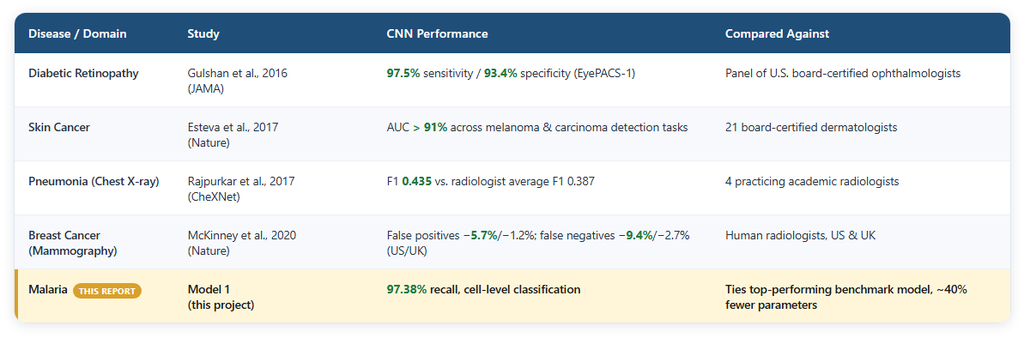

Five architectures were built and compared, all trained on the same 64x64, normalized image data. The table below summarizes how each one performed.

*Table 2: Comparative chart displaying the test accuracy, parasitized recall, and trainable parameters of the five CNNs constructed for this project.*

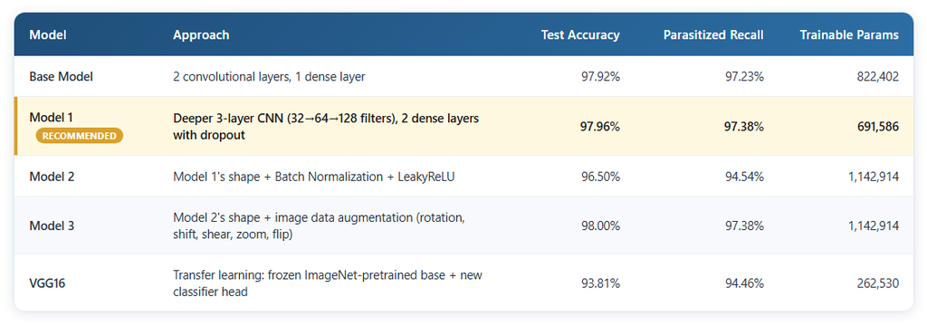

Model 3 edged out Model 1 on raw accuracy by a hair — 98.00% vs. 97.96%, a single image difference — and the Base Model trailed both by less than a tenth of a point. That's too close to call on accuracy alone, especially since these rankings shifted meaningfully between training runs (more on run-to-run variance below).

I'd still go with **Model 1**, though, because it ties Model 3 on the number that matters clinically: recall on the parasitized class, **97.38%**. Model 1 reaches the same bar with about **40% fewer parameters** than Model 3 and no augmentation pipeline to maintain. In other words, the same diagnostic performance at a lower training and computing cost, with one less moving part to validate and monitor in production. The two more complex approaches here — Model 2's Batch Normalization/LeakyReLU and VGG16's transfer learning — underperformed the simpler models, adding architectural and maintenance overhead without a corresponding performance gain.

## Analysis and Key Insights

Parasitized cells are visually distinct — a sharply stained pink or purple dot or ring, the parasite itself, that uninfected cells simply don't have. Averaging every image in a class together (a "mean image") washes that signal out almost completely, since the parasite's exact position and shape vary from cell to cell — the mean parasitized and mean uninfected cell images, averaged across the training set, are shown in the Appendix notebook below, and their near-identical appearance is exactly why simple pixel averaging cannot capture the parasite's features.

This confirms a simple pixel-averaging approach was never going to work here, and that a neural network's real strength — scanning for local texture and color wherever it shows up — is exactly what this problem needs. (The full side-by-side test accuracy and parasitized recall comparison across all five models is likewise shown in the Appendix notebook below.)

Three very different approaches — a plain baseline, a deeper from-scratch CNN, and that same deeper CNN trained with heavy augmentation — landed on essentially the same strong result here: within a tenth of a point of each other on accuracy, and tied on recall for two of the three. Batch Normalization/LeakyReLU and ImageNet transfer learning (VGG16) may seem like upgrades, but both methods produced worse results than observed with simpler models. That suggests the parasite's visual signature is distinctive enough that a reasonably capable CNN finds it reliably, whether or not it gets extra regularization, augmented data, or pretrained features. This is consistent with published research on this same dataset, where pre-trained CNN feature extractors proved similarly effective for malaria parasite detection (Rajaraman et al., 2018).

Reliability matters just as much as raw performance, though: in an earlier run of identical code, the augmented model (Model 3) was the weakest of the five, at 86.20% recall. In this run, it tied for best, at 97.38%. That's an 11-point swing on the metric that matters most, from run-to-run variance alone, which is not exactly the kind of consistency I'd want to stake a diagnosis on. Model 1 and the Base Model, by contrast, held steady across both runs. For anyone thinking about deploying a CNN in a clinical setting, that consistency is worth as much as the peak number.

## Limitations and Recommendations for Further Analysis

A few limitations should be addressed before this model goes anywhere near a clinical workflow:

- **Single-run evaluation:** Results shift meaningfully between training runs, as mentioned above. Before locking in a final model, metrics should be averaged across multiple runs, not simply one or two cases.
- **Dataset scope:** Every image here comes from one source dataset. It's untested against slides from different microscopes, stains, labs, or patient populations — any of which could shift performance. This isn't a hypothetical concern — a field trial of a related NIH-developed CNN-based malaria screening tool saw patient-level accuracy fall to 74–92% under real-world conditions in Sudan, well below typical lab-dataset benchmarks (Yu et al., 2023).
- **Fixed, low resolution:** Images were resized to 64x64 pixels to keep training efficient. That likely discards fine detail that could matter for edge cases — early-stage or low-parasitemia infections, for instance.
- **Cell-level, not patient-level:** The model classifies individual cells. A real workflow needs to aggregate many cell-level predictions into a patient-level prediction, and that aggregation logic with failure modes hasn't been built or tested yet.
- **No clinical or regulatory validation:** This is a medical decision-support tool. It needs a formal validation study against clinician ground truth, and regulatory review — per the U.S. Food and Drug Administration's (FDA) AI/ML-Based Software as a Medical Device (SaMD) Action Plan (2021) — before it goes beyond a pilot.

The next steps, in priority order: average results across multiple training runs before finalizing a model choice, and validate Model 1 against an external dataset to confirm it generalizes. From there, dig into why Model 2's Batch Normalization/LeakyReLU combination was less stable than the simpler Model 1, and try fine-tuning VGG16 by unfreezing its top layers instead of leaving the whole base frozen. Finally, test whether converting images to HSV color space — isolating hue from brightness — makes the parasite's signature even easier for a CNN to pick up; this conversion was explored during data prep but never actually modeled.

## Recommendations for Implementation

**My key recommendation:** Deploy Model 1 as an assistive layer the technician still oversees, not a replacement — consistent with WHO's guidance on human oversight of AI tools in health settings (WHO, 2021). It should flag likely-parasitized cells for priority review, letting one technician cover more slides rather than issuing diagnoses on its own.

**Who needs to do what:**

- *Lab operations / IT:* Build the model into the existing slide-scanning pipeline, with clear confidence thresholds — what gets auto-cleared, what gets flagged, what gets bumped to high-priority review.
- *Clinical stakeholders:* Actively test it against technician ground truth on current slides before shipping results.
- *Leadership / budget owners:* Plan for periodic retraining and re-validation — the run-to-run variance above isn't a one-time concern, and new microscopes, stains, or patient populations will need to be accounted for over time.

**Expected benefits and costs:** The upside is faster triage and more consistent monitoring of true infections — up to **~97%** of parasitized cells caught automatically here, especially valuable where specialists are scarce or caseloads are high. Costs are modest on the infrastructure side: Model 1's small footprint (691,586 parameters) runs on ordinary hardware, even edge devices, unlike the heavier VGG16 option. The real costs sit in validation, possible regulatory review, and ongoing retraining.

**The real risks:** run-to-run training variance affecting real-world reliability; the outsized cost of a false negative here (a missed infection) versus a false positive; possible distribution shift between the training data and real-world slides from different scanners, stains, or populations; and, the chance that technicians start deferring to the model instead of treating it as a second opinion.

**Further analysis needed:** Before any of this reaches real deployment, I'd want results averaged across multiple training runs so the final choice doesn't ride on one successful run; validation against an external, independently sourced dataset to confirm it generalizes; and, the cell-to-slide aggregation logic actually built and tested — that piece doesn't exist yet.

# Appendix

## References

- World Health Organization. Malaria. https://www.who.int/news-room/fact-sheets/detail/malaria
- Rajaraman, S., Antani, S. K., Poostchi, M., Silamut, K., Hossain, M. A., Maude, R. J., Jaeger, S., & Thoma, G. R. (2018). Pre-trained convolutional neural networks as feature extractors toward improved malaria parasite detection in thin blood smear images. *PeerJ, 6*, e4568. https://peerj.com/articles/4568/
- Lister Hill National Center for Biomedical Communications, U.S. National Library of Medicine. Malaria Datasets. https://ceb.nlm.nih.gov/repositories/malaria-datasets/
- Simonyan, K., & Zisserman, A. (2014). Very Deep Convolutional Networks for Large-Scale Image Recognition. *arXiv:1409.1556*. https://arxiv.org/abs/1409.1556
- U.S. Food and Drug Administration. (2021). Artificial Intelligence and Machine Learning (AI/ML)-Based Software as a Medical Device (SaMD) Action Plan. https://www.fda.gov/medical-devices/software-medical-device-samd/artificial-intelligence-and-machine-learning-software-medical-device
- World Health Organization. (2021). Ethics and governance of artificial intelligence for health: WHO guidance. https://www.who.int/publications/i/item/9789240029200
- Yu, H., Mohammed, F. O., Hamid, M. A., Yang, F., Kassim, Y. M., Mohamed, A. O., et al. (2023). Patient-level performance evaluation of a smartphone-based malaria diagnostic application. *Malaria Journal, 22*, 33. https://pmc.ncbi.nlm.nih.gov/articles/PMC9883923/
- Gulshan, V., Peng, L., Coram, M., et al. (2016). Development and Validation of a Deep Learning Algorithm for Detection of Diabetic Retinopathy in Retinal Fundus Photographs. *JAMA, 316*(22), 2402–2410. https://jamanetwork.com/journals/jama/fullarticle/2588763
- Esteva, A., Kuprel, B., Novoa, R. A., Ko, J., Swetter, S. M., Blau, H. M., & Thrun, S. (2017). Dermatologist-level classification of skin cancer with deep neural networks. *Nature, 542*(7639), 115–118. https://doi.org/10.1038/nature21056
- Rajpurkar, P., Irvin, J., Zhu, K., et al. (2017). CheXNet: Radiologist-Level Pneumonia Detection on Chest X-Rays with Deep Learning. *arXiv:1711.05225*. https://arxiv.org/abs/1711.05225
- McKinney, S. M., Sieniek, M., Godbole, V., et al. (2020). International evaluation of an AI system for breast cancer screening. *Nature, 577*, 89–94. https://www.nature.com/articles/s41586-019-1799-6
- Zhao, O. S., Kolluri, N., Anand, A., et al. (2020). Convolutional neural networks to automate the screening of malaria in low-resource countries. *PeerJ, 8*, e9674. https://doi.org/10.7717/peerj.9674
- Fuhad, K. M. F., Tuba, J. F., Sarker, M. R. A., Momen, S., Mohammed, N., & Rahman, T. (2020). Deep Learning Based Automatic Malaria Parasite Detection from Blood Smear and Its Smartphone Based Application. *Diagnostics, 10*(5), 329. https://doi.org/10.3390/diagnostics10050329

*The complete code, training runs, and full outputs referenced throughout this Appendix and the report above follow below — including the mean-image comparison and full model-comparison chart referenced in Analysis and Key Insights.*

## **Problem Definition**

**The context: Why is this problem important to solve?**

Malaria is diagnosed by having a trained lab technician examine a blood smear under a microscope and manually count and classify red blood cells as parasitized (infected with the *Plasmodium* parasite) or uninfected. This process is slow, requires a skilled specialist, and is subject to human fatigue and inter-observer variability — two technicians can disagree on the same slide. In low-resource, high-burden regions (where malaria is most common) there is often a shortage of trained microscopists, which delays diagnosis and treatment. According to the World Health Organization (WHO), malaria still causes several hundred thousand deaths a year, the majority in children under five; and, most of those deaths are preventable with fast, accurate diagnosis. An automated, image-based screening tool that flags parasitized cells with high sensitivity would let a single technician review far more slides, triage cases faster, and act as a second opinion that reduces missed diagnoses.

**The objectives:**

Build a deep learning (CNN-based) image classifier that, given a single microscopic image of a red blood cell, predicts whether the cell is **parasitized** or **uninfected**, with accuracy and recall (sensitivity) high enough to be useful as a diagnostic support tool.

**The key questions:**

- How well can a convolutional neural network distinguish parasitized from uninfected cells directly from raw pixel data?
- Does the model perform well without any hand-engineered features, or is pre-processing (blurring, HSV color-space conversion, normalization) needed to help it?
- Does image augmentation improve generalization, given how visually similar many cell images are?
- Does transfer learning (a network pre-trained on a very different domain, like ImageNet) transfer usefully to microscopic cell images?
- Which architecture gives the best trade-off between accuracy, recall on the parasitized class (missed infections are the costly error), and training cost?

**The problem formulation: What is it that we are trying to solve using data science?**

This is a **binary image classification** problem. Given an input image of a single cell (represented as a 3-channel pixel array), we want to learn a function that maps that image to one of two classes — **Parasitized** (1) or **Uninfected** (0) — by training a CNN on a labeled set of cell images and evaluating it on a held-out test set using accuracy, precision, recall, and the confusion matrix (recall on the parasitized class is the most clinically important metric, since a false negative means a missed infection).

**Data Description**

There are a total of 24,958 train and 2,600 test images (colored) that we have taken from microscopic images. These images are of the following categories:

**Parasitized:** The parasitized cells contain the Plasmodium parasite which causes malaria  
**Uninfected:** The uninfected cells are free of the Plasmodium parasites

## **Executive Summary**

This project addresses the critical need to automate malaria diagnosis from blood smear cell images to support faster, more consistent, and scalable screening. Our approach involved building and comparing five different Convolutional Neural Network (CNN) architectures: a baseline CNN, a deeper CNN, a model utilizing BatchNormalization and LeakyReLU, a model trained with image data augmentation, and a transfer-learning approach using VGG16. This run produced an extremely tight race at the top, with the augmented model, the deeper from-scratch CNN, and the baseline all landing within a single percentage point of each other on test accuracy. The deeper, from-scratch CNN (Model 1) is proposed as the final model: it matched the top model's 97.4% recall on the parasitized class at 98.0% test accuracy, while training with roughly 40% fewer parameters — making it the more efficient choice for an equivalent diagnostic result.

## **Data Preparation**

### **Mount the Drive**

```python
#Mounting Google Drive for access to datasets
from google.colab import drive
drive.mount('/content/drive')
```

### **Loading libraries**

```python
# Importing standard libraries for system and file operations (e.g., unzipping, moving folders)
import os
import shutil
from zipfile import ZipFile

# Importing libraries for image processing, mathematical operations, data handling, and visualization
import cv2
import numpy as np
import pandas as pd
import matplotlib.pyplot as plt
import seaborn as sns

# Importing TensorFlow and specific Keras components required to construct, train, and augment CNN models
import tensorflow as tf
from tensorflow.keras.models import Sequential
from tensorflow.keras.layers import (
    Conv2D, MaxPooling2D, Dense, Flatten, Dropout,
    BatchNormalization, LeakyReLU
)
from tensorflow.keras.optimizers import Adam
from tensorflow.keras.callbacks import EarlyStopping, ReduceLROnPlateau
from tensorflow.keras.utils import to_categorical
from tensorflow.keras.preprocessing.image import ImageDataGenerator
from tensorflow.keras.applications import VGG16

# Importing Scikit-learn modules for splitting data and evaluating model predictions
from sklearn.model_selection import train_test_split
from sklearn.metrics import confusion_matrix, classification_report

# Suppressing warning messages to maintain a clean console output
import warnings
warnings.filterwarnings('ignore')

# Setting seed for reproducibility as we train CNN
SEED = 88
np.random.seed(SEED)
tf.random.set_seed(SEED)

%matplotlib inline
```

### **Let us load the data**

**Note:**

- You must download the dataset from the link provided on Olympus and upload the same to your Google Drive. Then unzip the folder.

```python
# Defining primary and secondary directory for dataset from Google Drive.
# Checking if local directory already exists, if not, checking Google Drive for
# target dataset.
# If folder/zip is found, unzipping/copying folder to local Google Colab environment.

DRIVE_DATA_DIR = '/content/drive/MyDrive/MIT/Capstone'
LOCAL_DATA_DIR = '/content/cell_images'

if not os.path.exists(LOCAL_DATA_DIR):
    # zip_path and folder_path correctly constructed relative to DRIVE_DATA_DIR
    zip_path = os.path.join(DRIVE_DATA_DIR, 'cell_images.zip')
    folder_path = os.path.join(DRIVE_DATA_DIR, 'cell_images')

    if os.path.exists(zip_path):
        with ZipFile(zip_path, 'r') as zf:
            zf.extractall('/content/')
    elif os.path.exists(folder_path):
        shutil.copytree(folder_path, LOCAL_DATA_DIR)
    else:
        raise FileNotFoundError(
            "Couldn't find 'cell_images.zip' or a 'cell_images' folder in "
            f"'{DRIVE_DATA_DIR}'. Update DRIVE_DATA_DIR above (or the file/"
            "folder name) to match wherever you uploaded the dataset."
        )

DATA_DIR = LOCAL_DATA_DIR

print("Classes found:", os.listdir(DATA_DIR))
```

```
Classes found: ['test', 'train']
```

The extracted folder has different folders for train and test data which will contain the different sizes of images for parasitized and uninfected cells within the respective folder name.

The size of all images must be the same and should be converted to 4D arrays so that they can be used as an input for the convolutional neural network. Also, we need to create the labels for both types of images to be able to train and test the model.

Let's do the same for the training data first and then we will use the same code for the test data as well.

#### **Checking Original Dimensions of Images Before Resizing**

```python
# Checking the original dimensions of a few raw images before resizing
# to demonstrate why resizing to a uniform shape (like 64x64) is necessary.
sample_folder = os.path.join(DATA_DIR, 'train', 'parasitized')

print("Original shapes of a few sample images before resizing:")
valid_samples_checked = 0

for fname in os.listdir(sample_folder):
    fpath = os.path.join(sample_folder, fname)
    img = cv2.imread(fpath)
    if img is not None:
        print(f"Original Shape: {img.shape}")
        valid_samples_checked += 1
    if valid_samples_checked >= 5:
        break
```

```
Original shapes of a few sample images before resizing:
Original Shape: (115, 118, 3)
Original Shape: (127, 136, 3)
Original Shape: (136, 139, 3)
Original Shape: (130, 121, 3)
Original Shape: (163, 184, 3)
```

**Observations:** The raw shapes of the images above show a range of 115-184 pixels in terms of height and width of the selected images. In order for our CNN models to utilize the image data properly, we need to configure each image to a uniform, standard size (such as 64x64 pixels). Convolutional neural networks require a fixed input shape so they can process the data in batches and pass it through the network's layers correctly.

#### **Resizing Images**

```python
# Setting the standard image size and paths for the training and test datasets.
# Defining a function, `load_images_from_folder`, which iterates through class folders,
# reads the images, converts their color format from BGR (OpenCV default) to RGB,
# resizes them to 64x64, and extracts their labels (0 for parasitized, 1 for uninfected).
# Finally, loading the actual image data and labels into memory for both train and test sets.

IMG_SIZE = 64  # every image is resized to 64 x 64 x 3

TRAIN_DIR = os.path.join(DATA_DIR, 'train')
TEST_DIR = os.path.join(DATA_DIR, 'test')

def load_images_from_folder(base_dir, img_size=IMG_SIZE):
    """
    Walk a directory that contains one sub-folder per class
    (parasitized / uninfected), read every image with OpenCV, resize it to
    (img_size, img_size), and return:
      - images as a 4D numpy array (n_samples, img_size, img_size, 3)
      - labels as a 1D numpy array of integer class ids
      - the class-name -> integer-label mapping that was used
    """
    classes = sorted(os.listdir(base_dir))  # e.g. ['parasitized', 'uninfected']
    class_to_label = {cls_name: idx for idx, cls_name in enumerate(classes)}

    images, labels = [], []
    for cls_name in classes:
        cls_dir = os.path.join(base_dir, cls_name)
        for fname in os.listdir(cls_dir):
            fpath = os.path.join(cls_dir, fname)
            img = cv2.imread(fpath)
            if img is None:          # skip unreadable / non-image files (e.g. Thumbs.db)
                continue
            img = cv2.cvtColor(img, cv2.COLOR_BGR2RGB)
            img = cv2.resize(img, (img_size, img_size))
            images.append(img)
            labels.append(class_to_label[cls_name])

    return np.array(images), np.array(labels), class_to_label


train_data, train_labels, class_to_label = load_images_from_folder(TRAIN_DIR)
test_data, test_labels, _ = load_images_from_folder(TEST_DIR)

label_names = list(class_to_label.keys())
print("Class mapping:", class_to_label)
```

```
Class mapping: {'parasitized': 0, 'uninfected': 1}
```

### **Check the shape of train and test images**

```python
#Checking the shape of the train and test image sets separately
print("Train images shape:", train_data.shape)
print("Test images shape:", test_data.shape)
```

```
Train images shape: (24958, 64, 64, 3)
Test images shape: (2600, 64, 64, 3)
```

**Observations:**

The training set contains 24,958 images, and the testing set contains 2,600 images. Based on the output, we can conclude that the raw images have been successfully resized to the uniform 64x64 pixel shape we defined earlier. Additionally, the '3' seen in the last position of each shape array represents the 3 color channels (Red, Green, Blue) that the CNN will use to identify visual patterns.

### **Check the shape of train and test labels**

```python
#Checking the shape of the train and test labels separately.
print("Train labels shape:", train_labels.shape)
print("Test labels shape:", test_labels.shape)
```

```
Train labels shape: (24958,)
Test labels shape: (2600,)
```

**Observations:** The output indicates the training set has 24,958 labels and the testing set has 2,600 labels. From this we can conclude there are no images without a label in either image set.

### **Check the minimum and maximum range of pixel values for train and test images**

```python
#Checking the min and max values of pixels in the train and test image sets before normalization
print("Train pixel value range:", train_data.min(), "-", train_data.max())
print("Test pixel value range:", test_data.min(), "-", test_data.max())
```

```
Train pixel value range: 0 - 255
Test pixel value range: 0 - 255
```

**Observations:** The raw images obtained from `cv2.imread` have pixel values holding 8-bit integers. The range of the pixels in the raw image set should range from 0 - 255 which is verified in the code above. Additionally, we can conclude these images have not been properly normalized for CNN analysis. We will need to normalize these images so the pixel values hold a range between 0 - 1.0.

**Note:** Normalization is necessary because large, unscaled inputs (0 - 255 pixel values) negatively affect the efficiency, and stability, of gradient-based training.

### **Count the number of values in both uninfected and parasitized**

```python
#Checking counts of each class type of both train and test sets
label_lookup = {v: k for k, v in class_to_label.items()}

train_counts = pd.Series(train_labels).map(label_lookup).value_counts()
test_counts = pd.Series(test_labels).map(label_lookup).value_counts()

print("Train set class counts:\n", train_counts)
print("\nTest set class counts:\n", test_counts)
```

```
Train set class counts:
 parasitized    12582
uninfected     12376
Name: count, dtype: int64

Test set class counts:
 parasitized    1300
uninfected     1300
Name: count, dtype: int64
```

**Observations:**

The output reveals the respective class counts for both the training and testing sets. The test set maintains a clean 50/50 split, with exactly 1,300 images per class. While there is a slight difference in the class counts for the training set (12,582 parasitized vs. 12,376 uninfected), the disparity is extremely small. Because this split is nearly evenly balanced, we won't need to worry about the CNN developing a prediction bias toward a majority class during training.

### **Normalize the images**

```python
#Normalizing the pixel values of train and test image sets to a range 0 - 1.0
train_data = train_data.astype('float32') / 255.0
test_data = test_data.astype('float32') / 255.0

print("Train pixel range after normalization:", train_data.min(), "-", train_data.max())
print("Test pixel range after normalization:", test_data.min(), "-", test_data.max())
```

```
Train pixel range after normalization: 0.0 - 1.0
Test pixel range after normalization: 0.0 - 1.0
```

**Observations:**

These results indicate that the pixel values have been successfully scaled down to a range between 0.0 - 1.0. This normalized data is what the neural network will actually train on. By scaling the inputs to this smaller, consistent range, we ensure they align with the small random weights initialized inside the network. Ultimately, this normalization process allows the model's training to converge much faster and more reliably.

### **Plot to check if the data is balanced**

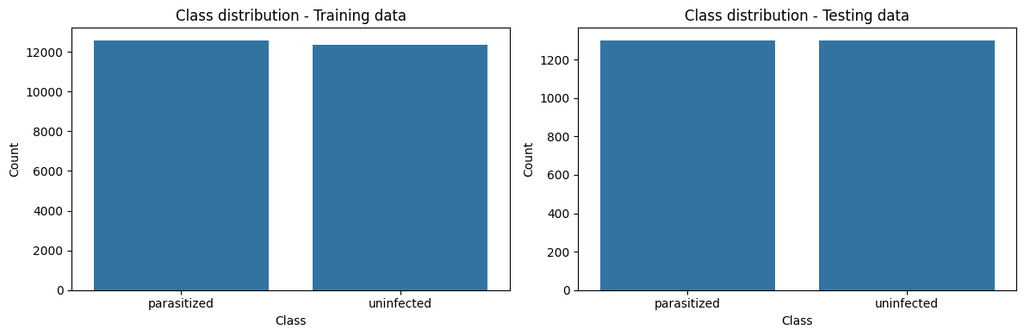

```python
#Plotting side-by-side figures showing the class distribution (parasitized/uninfected) of the training and testing data sets
fig, axes = plt.subplots(1, 2, figsize=(12, 4))

sns.countplot(x=pd.Series(train_labels).map(label_lookup), ax=axes[0])
axes[0].set_title("Class distribution - Training data")
axes[0].set_xlabel("Class")
axes[0].set_ylabel("Count")

sns.countplot(x=pd.Series(test_labels).map(label_lookup), ax=axes[1])
axes[1].set_title("Class distribution - Testing data")
axes[1].set_xlabel("Class")
axes[1].set_ylabel("Count")

plt.tight_layout()
plt.show()
```

**Observations:**

The bar charts confirm the class distribution we noted earlier when counting the raw values. The training set is practically evenly balanced despite the extremely small disparity we observed previously, and the test set maintains a flawless 50/50 split. Because both of our datasets are clean and balanced, we can trust that standard accuracy will be a reliable metric for our CNN models. We won't have to worry about the network inflating its performance by simply predicting a majority class. However, keeping our clinical objective in mind, we will still need to carefully monitor recall and the confusion matrices later on to ensure the models are minimizing missed infections (false negatives).

### **Data Exploration**

Let's visualize the images from the train data

#### **Visualizing First Occurrences**

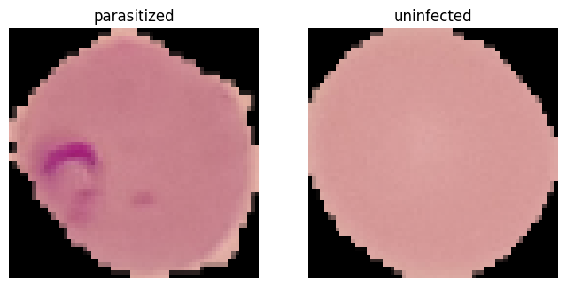

```python
#Finding the first occurrence of each class and displaying a visualization
plt.figure(figsize=(8, 4))
for i, cls_name in enumerate(class_to_label):
    idx = np.where(train_labels == class_to_label[cls_name])[0][0] # finds and saves the indices of the first occurrence of each class
    plt.subplot(1, 2, i + 1)
    plt.imshow(train_data[idx])
    plt.title(cls_name)
    plt.axis('off')
plt.show()
```

**Observations:**

Visually, it is apparent that parasitized cells commonly display one or more markedly stained (often purple or pink), dot- or ring-shaped regions within the cell. These distinct spots represent the actual parasite and are noticeably absent in the 'uninfected' cells. Ultimately, these sharp areas of contrast and color variance are exactly the kinds of visual patterns our CNN will be searching for as we train it to differentiate between infected and healthy cells.

#### **Visualize the images with subplot(6, 6) and figsize = (12, 12)**

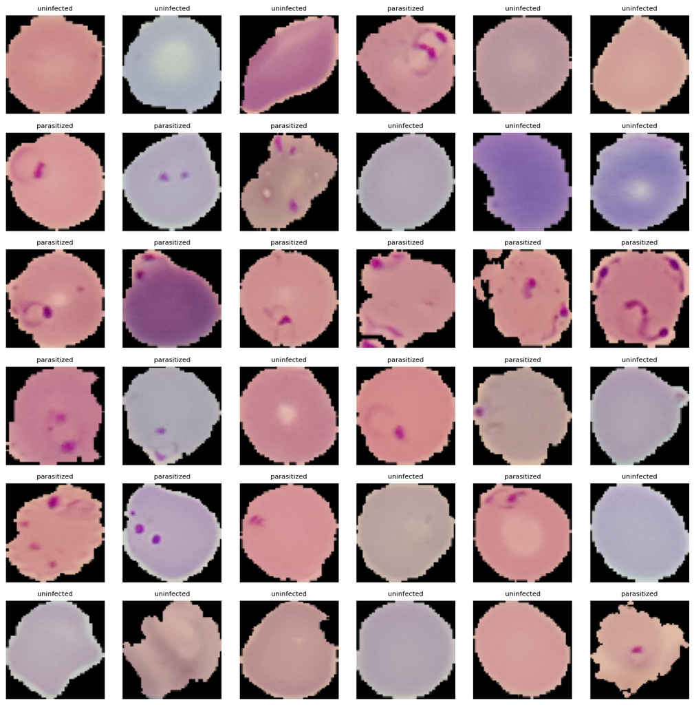

```python
#Randomly selecting 36 indices from training set and displaying the cell associated
#with a label - parasitized vs uninfected
#Visualizing data to be fed into CNN model
fig, axes = plt.subplots(6, 6, figsize=(12, 12))
rand_idx = np.random.choice(len(train_data), 36, replace=False)

for ax, idx in zip(axes.flatten(), rand_idx):
    ax.imshow(train_data[idx])
    ax.set_title(label_lookup[train_labels[idx]], fontsize=8)
    ax.axis('off')

plt.tight_layout()
plt.show()
```

**Observations:**

Examining this larger, randomly generated 6x6 grid provides a much clearer picture of the natural variability present in our dataset. While the infected cells still clearly display the distinct purple/pink stained regions of the parasite we noted earlier, the overall appearance of the cells varies widely across both classes. It is easy to spot differences in cell shape and size, completely random orientations, and varying background staining intensities—ranging from very pale pink to deep purple. We even see occasional artifacts or overlapping cells.

Because of this high degree of natural variability, it becomes obvious why we'll be testing data augmentation techniques (like random rotations, shifts, and flips) later in our modeling phase. By synthetically expanding this variability during training, we can prevent the CNN from simply memorizing specific cell orientations or lighting conditions. Instead, we encourage the network to generalize the actual parasite's signature.

#### **Plotting the mean images for parasitized and uninfected**

```python
#Defining a function averaging every image belonging to one class, pixel-by-pixel and returning the average image.
def mean_image(data, labels, label_value):

    return data[labels == label_value].mean(axis=0)
```

##### **Mean image for parasitized**

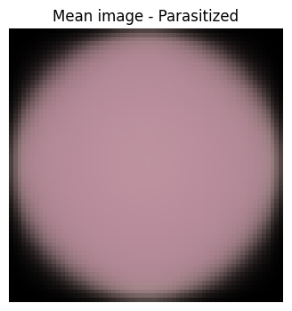

```python
#Finding the average image for images labeled 'parasitized' and plotting the average image.
parasitized_label = class_to_label['parasitized']
mean_parasitized = mean_image(train_data, train_labels, parasitized_label)

plt.figure(figsize=(4, 4))
plt.imshow(mean_parasitized)
plt.title("Mean image - Parasitized")
plt.axis('off')
plt.show()
```

##### **Mean image for uninfected**

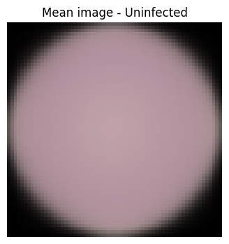

```python
#Finding the average image for images labeled 'uninfected' and plotting the average image.
uninfected_label = class_to_label['uninfected']
mean_uninfected = mean_image(train_data, train_labels, uninfected_label)

plt.figure(figsize=(4, 4))
plt.imshow(mean_uninfected)
plt.title("Mean image - Uninfected")
plt.axis('off')
plt.show()
```

**Observations:**

These mean images appear incredibly similar at first glance. Aside from some minor shading differences, it's actually quite difficult to immediately determine which averaged image represents the infected cells. The mean uninfected cell looks like a smooth, fairly uniform blob because averaging the random positions and shapes blurs everything into a soft, round shape. The mean parasitized image only shows a very faint, slightly darker patch off-center where the infected regions most commonly appear. Because the exact location of the parasite varies so much from image to image, the averaging process washes out almost all the fine details observed so clearly in the single-image views earlier.

This visual "wash-out" confirms why we need a more advanced approach to identify these infected cells. Simple linear models looking at raw, average pixels just won't cut it here. Instead, this highlights why Convolutional Neural Networks (CNNs) are the right tool for the job. A CNN utilizes sliding convolutional filters to actively scan for specific local textures and color signatures (like those sharp purple/pink stains) regardless of where they happen to appear within the image.

#### **Visualize Input Data - CNN POV**

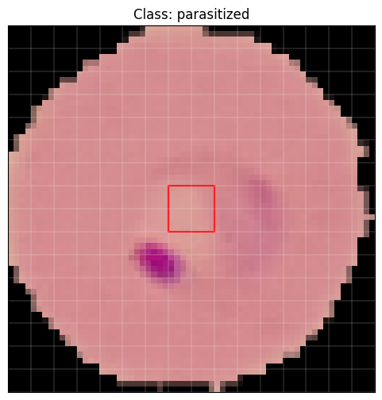

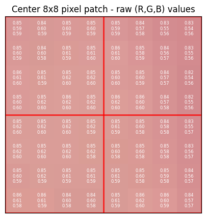

```
This image's shape: (64, 64, 3), pixel range: 0.000-0.875 (normalized)
```

```python
# Visualizing a random image in the training set in the manner in
# which our CNN will view the image.
# Followed by a close-up 8x8 pulled from the center of the image to view
# associated, normalized values.
rand_idx = np.random.randint(0, len(train_data))
img = train_data[rand_idx]
cls_name = label_names[train_labels[rand_idx]]

# Pulling the zoom-in patch from the CENTER of the image, not the corner -
# the corners are black background outside the cell (see the mean-image
# plots earlier), so a corner patch will almost always be all zeros.
# The center is where the actual cell content lives.
patch_size = 8
center = IMG_SIZE // 2
start = center - patch_size // 2
end = start + patch_size

plt.figure(figsize=(6, 6))
plt.imshow(img)
plt.title(f"Class: {cls_name}")

grid_step = 4
for x in np.arange(-0.5, IMG_SIZE, grid_step):
    plt.axvline(x=x, color='white', linewidth=0.3, alpha=0.6)
for y in np.arange(-0.5, IMG_SIZE, grid_step):
    plt.axhline(y=y, color='white', linewidth=0.3, alpha=0.6)

#Red box showing exactly where the 8x8 patch below is pulled from
import matplotlib.patches as patches
rect = patches.Rectangle((start - 0.5, start - 0.5), patch_size, patch_size,
                          linewidth=1.5, edgecolor='red', facecolor='none')
plt.gca().add_patch(rect)

plt.xticks([]); plt.yticks([])
plt.show()

patch = img[start:end, start:end, :]

fig, ax = plt.subplots(figsize=(5, 5))
ax.imshow(patch)
for i in range(patch.shape[0]):
    for j in range(patch.shape[1]):
        r, g, b = patch[i, j]
        ax.text(j, i, f"{r:.2f}\n{g:.2f}\n{b:.2f}", ha='center', va='center', fontsize=6, color='white')

#Add red grid lines to match the overall image's grid
for x in np.arange(-0.5 + (start % grid_step), patch_size, grid_step):
    ax.axvline(x=x, color='red', linewidth=2, alpha=0.8)
for y in np.arange(-0.5 + (start % grid_step), patch_size, grid_step):
    ax.axhline(y=y, color='red', linewidth=2, alpha=0.8)

ax.set_title(f"Center {patch_size}x{patch_size} pixel patch - raw (R,G,B) values")
ax.set_xticks([]); ax.set_yticks([])
plt.show()

print(f"This image's shape: {img.shape}, pixel range: {img.min():.3f}-{img.max():.3f} (normalized)")
```

**Observations:**

The 8x8 pixel patch above offers a literal "under-the-hood" look at exactly how our CNN perceives these blood cells. Instead of seeing a smooth pink or purple blob, the network sees a dense grid of numbers representing the intensity of the Red, Green, and Blue channels for every single pixel.

This microscopic view illustrates why we normalized our data. As evident here, the values inside this patch are all tightly bounded between 0.0 - 1.0, rather than sitting on the raw 0 - 255 scale.

**Think About It:** Neural networks initialize with very small, random weights. If we fed massive, unscaled pixel values (like 240 or 255) directly into the network, those huge inputs would multiply with the internal weights and cause our gradients to become unstable during training. This instability can make the model highly unpredictable or even completely unable to learn. By scaling everything down to a consistent 0.0 - 1.0 range, we ensure that the math stays manageable, allowing our CNN to reliably and efficiently learn the exact mathematical signatures of a malaria-infected cell.

### **Converting RGB to HSV of Images using OpenCV**

#### **Converting the train data**

```python
#cv2 expects 8-bit images for color-space conversion, so scale back up to
#0-255 first, convert, then we can decide later whether to use this
#representation for modeling.
train_data_hsv = np.array([
    cv2.cvtColor((img * 255).astype('uint8'), cv2.COLOR_RGB2HSV)
    for img in train_data
])
print("Train HSV data shape:", train_data_hsv.shape)
```

```
Train HSV data shape: (24958, 64, 64, 3)
```

**Observations:** The results show the training set post-conversion holds 24,958 images (64x64 pixels) which aligns with the count we gathered pre-conversion.

#### **Converting the test data**

```
Test HSV data shape: (2600, 64, 64, 3)
```

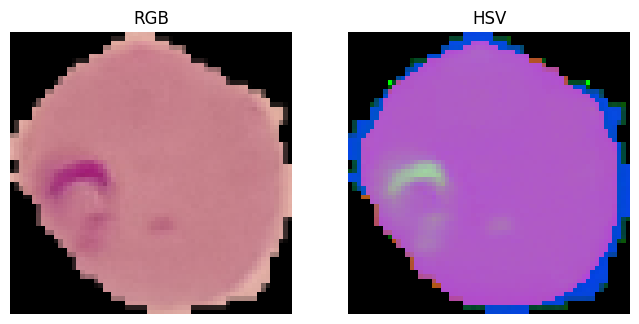

```python
#Converting the test image data from RGB to HSV to separate color into hue/saturation/value channels
#and showing the data set shape post-conversion
test_data_hsv = np.array([
    cv2.cvtColor((img * 255).astype('uint8'), cv2.COLOR_RGB2HSV)
    for img in test_data
])
print("Test HSV data shape:", test_data_hsv.shape)

#Showing side-by-side images of the first image in the training data set before
#and after RGB-HSV conversion
fig, axes = plt.subplots(1, 2, figsize=(8, 4))
axes[0].imshow(train_data[0])
axes[0].set_title("RGB")
axes[0].axis('off')
axes[1].imshow(train_data_hsv[0])
axes[1].set_title("HSV")
axes[1].axis('off')
plt.show()
```

**Observations:**

The output confirms that our testing set still contains the expected 2,600 images at our standardized 64x64 pixel resolution. The conversion process worked without dropping any data.

Visually, the newly converted HSV image looks quite different from our standard RGB view. This is because the HSV color space separates the image into distinct Hue (color), Saturation (intensity), and Value (brightness) channels, rather than entangling the color information across Red, Green, and Blue (RGB). By isolating the actual color into its own channel, we could potentially make it much easier for a CNN to lock directly onto the specific pink/purple hue of the parasitic regions.

While this is a highly promising technique that we've noted down for future improvements, we're going to stick with our standard RGB images for our initial modeling phase to maintain a consistent baseline.

### **Processing Images using Gaussian Blurring**

#### **Gaussian Blurring on train data**

```python
#Applying blurring to the images in the training set and printing the data set shape post-application
train_data_blur = np.array([
    cv2.GaussianBlur(img, (5, 5), 0) for img in train_data
])
print("Blurred train data shape:", train_data_blur.shape)
```

```
Blurred train data shape: (24958, 64, 64, 3)
```

**Observations:** The shape outputs demonstrate the training set post-blurring contains 24,958 images which is consistent with the count obtained prior. Each image maintains its 64x64 size.

#### **Gaussian Blurring on test data**

```
Blurred test data shape: (2600, 64, 64, 3)
```

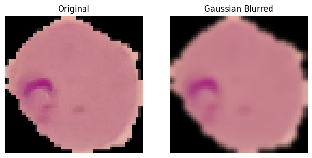

```python
#Applying blurring to the images in the testing set and printing the shape of the
#data set post-application
test_data_blur = np.array([
    cv2.GaussianBlur(img, (5, 5), 0) for img in test_data
])
print("Blurred test data shape:", test_data_blur.shape)

#Plotting a side-by-side of the first image of the training set before and after
#blurring is applied
fig, axes = plt.subplots(1, 2, figsize=(8, 4))
axes[0].imshow(train_data[0])
axes[0].set_title("Original")
axes[0].axis('off')
axes[1].imshow(train_data_blur[0])
axes[1].set_title("Gaussian Blurred")
axes[1].axis('off')
plt.show()
```

**Observations:**

A quick comparison with the blurred image on the right shows that Gaussian blurring definitely smooths out the overall pixel-level noise. However, it also significantly softens the small, fine-grained details of the parasite structures—which is the exact signal our CNN needs to identify.

**Think About It:**  
Gaussian blurring is a classic image processing tool, but it comes with a major clinical trade-off here. On one hand, smoothing out background noise could hypothetically help the network avoid getting distracted by irrelevant artifacts. On the other hand, the heavy blurring risks washing out the sharp, distinctive pink/purple edges of the parasite, thereby reducing the visibility of critical diagnostic features.

Because our primary goal is detecting those specific, sharp inclusions, blurring might actually do more harm than good in this context. Instead, a much better direction for us to take is data augmentation (like random rotations, shifts, and flips). Augmentation allows us to add useful, realistic variations to our training set without actively destroying the delicate features we need our model to learn!

## **Model Building**

### **Base Model**

#### **Importing the required libraries for building and training our Model**

```python
# All modeling libraries (Sequential, layers, optimizers, callbacks,
# ImageDataGenerator, VGG16, sklearn metrics) were already imported in the
# "Loading libraries" cell above - kept as a separate heading here to match
# the notebook's structure.
print("Using TensorFlow", tf.__version__)
```

```
Using TensorFlow 2.20.0
```

##### TensorFlow Stability Check

```python
# Building a small dummy model on random data to confirm this TensorFlow
# install can build, compile, train, and predict without errors, and that
# the loss stays a normal finite number (not NaN/Inf, which would signal a
# broken install or a bad GPU/driver combo). This uses fake data, not the
# malaria dataset, so it can run before anything else in the notebook.


print(f"TensorFlow version: {tf.__version__}")
print(f"Keras version: {tf.keras.__version__}")

gpu_devices = tf.config.list_physical_devices('GPU')
print(f"GPU available: {bool(gpu_devices)} ({len(gpu_devices)} device(s))")

try:
    # Fake data: 200 samples, 10 features each, binary labels
    X_dummy = np.random.rand(200, 10).astype('float32')
    y_dummy = np.random.randint(0, 2, size=(200,)).astype('float32')

    test_model = Sequential([
        Dense(16, activation='relu', input_shape=(10,)),
        Dense(8, activation='relu'),
        Dense(1, activation='sigmoid')
    ])
    test_model.compile(optimizer='adam', loss='binary_crossentropy', metrics=['accuracy'])

    history = test_model.fit(X_dummy, y_dummy, epochs=3, batch_size=16, verbose=0)
    preds = test_model.predict(X_dummy, verbose=0)

    final_loss = history.history['loss'][-1]
    loss_is_finite = np.isfinite(final_loss)
    preds_are_finite = np.all(np.isfinite(preds))

    if loss_is_finite and preds_are_finite:
        print(f"\n✅ TensorFlow {tf.__version__} built, trained, and predicted successfully "
              f"(final dummy loss: {final_loss:.4f}). This version is stable and safe to use.")
    else:
        print(f"\n⚠️ Training ran but produced non-finite values "
              f"(loss finite: {loss_is_finite}, predictions finite: {preds_are_finite}). "
              "Investigate before trusting results from this environment.")

except Exception as e:
    print(f"\n❌ TensorFlow stability check FAILED: {type(e).__name__}: {e}")
    print("This environment/version may not be safe to use for the rest of the notebook.")
```

```
TensorFlow version: 2.20.0
Keras version: 3.13.2
GPU available: False (0 device(s))

✅ TensorFlow 2.20.0 built, trained, and predicted successfully (final dummy loss: 0.6967). This version is stable and safe to use.
```

#### **One Hot Encoding the train and test labels**

```python
#One-hot encoding train and test labels to be properly read by CNN model
train_labels_ohe = to_categorical(train_labels, num_classes=2)
test_labels_ohe = to_categorical(test_labels, num_classes=2)

print("Train labels shape after one-hot encoding:", train_labels_ohe.shape)
print("Test labels shape after one-hot encoding:", test_labels_ohe.shape)
```

```
Train labels shape after one-hot encoding: (24958, 2)
Test labels shape after one-hot encoding: (2600, 2)
```

**Observations:** The printed output displays the shapes of the train and test label sets after being one-hot encoded. The training set holds 24,958 labels with each label belonging to one of two classes. The testing set holds 2,600 labels and follows the same class organization as the training set. The code above verifies the number of labels in both the train and tests sets after one-hot encoding matches the number of labels before the conversion.

```python
#Checking for confirmation of one-hot encoding of class labels
print(f"Class name:            {cls_name}")
print(f"Raw integer label:     {train_labels[rand_idx]}")
print(f"One-hot encoded label: {train_labels_ohe[rand_idx]}")
```

```
Class name:            parasitized
Raw integer label:     0
One-hot encoded label: [1. 0.]
```

**Observations:** Looking above, it is clear all class labels have been one-hot encoded to show either a 0 (parasitized) or a 1 (uninfected) to be easily read by the network.

#### **Global Helper Functions**

```python
# =========================================================================
# GLOBAL HELPER FUNCTIONS
# Defined here so they are available to all models regardless of execution order.
# =========================================================================

def evaluate_and_plot_confusion_matrix(model, data, labels_ohe, title):
    """Predict on `data`, plot a confusion matrix heatmap, and print the
    sklearn classification report (precision/recall/F1 per class)."""
    y_pred = np.argmax(model.predict(data, verbose=0), axis=1)
    y_true = np.argmax(labels_ohe, axis=1)

    #Plotting a confusion matrix heatmap
    cm = confusion_matrix(y_true, y_pred)
    plt.figure(figsize=(5, 4))
    sns.heatmap(cm, annot=True, fmt='d', cmap='Blues',
                xticklabels=label_names, yticklabels=label_names)
    plt.xlabel("Predicted")
    plt.ylabel("Actual")
    plt.title(title)
    plt.show()

    #Printing classification report of model performance (precision/recall/F1 per class)
    print(classification_report(y_true, y_pred, target_names=label_names))
    return y_true, y_pred

def plot_history(history, title):
    """Plot the performance of a model with side-by-side view of train vs validation accuracy
    and train vs validation loss figures."""
    fig, axes = plt.subplots(1, 2, figsize=(12, 4))

    axes[0].plot(history.history['accuracy'], label='Train Accuracy')
    axes[0].plot(history.history['val_accuracy'], label='Validation Accuracy')
    axes[0].set_title(f"{title} - Accuracy")
    axes[0].set_xlabel("Epoch")
    axes[0].legend()

    axes[1].plot(history.history['loss'], label='Train Loss')
    axes[1].plot(history.history['val_loss'], label='Validation Loss')
    axes[1].set_title(f"{title} - Loss")
    axes[1].set_xlabel("Epoch")
    axes[1].legend()

    plt.tight_layout()
    plt.show()
```

#### **Building the model**

```python
#Building the architecture of the Base Model using Conv2D, MaxPooling2D, Flatten, and Dense layers.
def build_base_model():
    model = Sequential([
        Conv2D(32, (3, 3), activation='relu', input_shape=(IMG_SIZE, IMG_SIZE, 3)),
        MaxPooling2D(pool_size=(2, 2)),

        Conv2D(64, (3, 3), activation='relu'),
        MaxPooling2D(pool_size=(2, 2)),

        Flatten(),
        Dense(64, activation='relu'),
        Dropout(0.3),
        Dense(2, activation='softmax')
    ])
    return model


base_model = build_base_model()
base_model.summary()
```

```
Model: "sequential_1"
```

```
┏━━━━━━━━━━━━━━━━━━━━━━━━━━━━━━━━━┳━━━━━━━━━━━━━━━━━━━━━━━━┳━━━━━━━━━━━━━━━┓
┃ Layer (type)                    ┃ Output Shape           ┃       Param # ┃
┡━━━━━━━━━━━━━━━━━━━━━━━━━━━━━━━━━╇━━━━━━━━━━━━━━━━━━━━━━━━╇━━━━━━━━━━━━━━━┩
│ conv2d (Conv2D)                 │ (None, 62, 62, 32)     │           896 │
├─────────────────────────────────┼────────────────────────┼───────────────┤
│ max_pooling2d (MaxPooling2D)    │ (None, 31, 31, 32)     │             0 │
├─────────────────────────────────┼────────────────────────┼───────────────┤
│ conv2d_1 (Conv2D)               │ (None, 29, 29, 64)     │        18,496 │
├─────────────────────────────────┼────────────────────────┼───────────────┤
│ max_pooling2d_1 (MaxPooling2D)  │ (None, 14, 14, 64)     │             0 │
├─────────────────────────────────┼────────────────────────┼───────────────┤
│ flatten (Flatten)               │ (None, 12544)          │             0 │
├─────────────────────────────────┼────────────────────────┼───────────────┤
│ dense_3 (Dense)                 │ (None, 64)             │       802,880 │
├─────────────────────────────────┼────────────────────────┼───────────────┤
│ dropout (Dropout)               │ (None, 64)             │             0 │
├─────────────────────────────────┼────────────────────────┼───────────────┤
│ dense_4 (Dense)                 │ (None, 2)              │           130 │
└─────────────────────────────────┴────────────────────────┴───────────────┘
```

```
 Total params: 822,402 (3.14 MB)
```

```
 Trainable params: 822,402 (3.14 MB)
```

```
 Non-trainable params: 0 (0.00 B)
```

**Insights:**

- **Conv2D:** This is our feature extractor. It uses sliding filters to scan the image for distinct patterns, like the marked pink/purple stains of the parasite.
- **MaxPooling2D:** This acts as a summarizer. It shrinks the spatial dimensions of the image, keeping only the most prominent features while drastically reducing the computational load.
- **Flatten:** Just like it sounds, this layer takes our 2D feature maps and flattens them into a single 1D column of numbers so our final classification layers can read them.
- **Dense:** These are our fully connected, decision-making layers. They take all the extracted features and learn how to combine them to make the final prediction.
- **Dropout:** This is our primary defense against overfitting. By randomly turning off a percentage of neurons during training, we force the network to learn robust, generalized patterns rather than simply memorizing the training images.

**Observations:**

Reviewing the code and summary above reveals a few specific numbers driving our Base Model:

- **Filters (32 and 64):** Our first Conv2D layer uses 32 filters to catch basic patterns, and the second steps up to 64 to catch more complex, combined features.
- **Kernel Size (3, 3):** This means our convolutional filters are looking at the image in tiny 3x3 pixel grids at a time.
- **Pool Size (2, 2):** Our MaxPooling2D layers cut the image dimensions exactly in half at each step (e.g., from 62x62 down to 31x31).
- **Dense (64):** We use 64 neurons in our hidden dense layer to process all of those flattened features.
- **Dropout (0.3):** We are randomly dropping exactly 30% of the active neurons in that layer during each training step.
- **Dense (2):** Our final output layer has exactly 2 neurons, matching our two classes (Parasitized and Uninfected). We use a **softmax** activation here so the model outputs a clean probability percentage for each class.

#### **Compiling the model**

```python
#Compiling the Base Model with categorical crossentropy loss and the Adam optimizer.
base_model.compile(
    loss='categorical_crossentropy',
    optimizer=Adam(learning_rate=0.001),
    metrics=['accuracy']
)
```

#### **Using Callbacks**

```python
#Applying EarlyStopping to monitor the trend of validation loss. Saves the best performance and stops learning after
#no improvement after 3 epochs.
early_stop = EarlyStopping(monitor='val_loss', patience=3, restore_best_weights=True)
#Applying ReduceLROnPlateau to monitor the trend of validation loss. Reduces the learning rate by 0.5
#after no improvement after 2 epochs.
reduce_lr = ReduceLROnPlateau(monitor='val_loss', factor=0.5, patience=2, min_lr=1e-6)

base_callbacks = [early_stop, reduce_lr]
```

#### **Fit and train our Model**

```python
#Training our Base Model over 20 epochs with a batch size of 32 and saving the results in history_base
history_base = base_model.fit(
    train_data, train_labels_ohe,
    validation_split=0.2,
    epochs=20,
    batch_size=32,
    callbacks=base_callbacks,
    verbose=1
)
```

```
624/624 ━━━━━━━━━━━━━━━━━━━━ 116s 183ms/step - accuracy: 0.7830 - loss: 0.4654 - val_accuracy: 0.9595 - val_loss: 0.1082 - learning_rate: 0.0010
624/624 ━━━━━━━━━━━━━━━━━━━━ 135s 173ms/step - accuracy: 0.9256 - loss: 0.1984 - val_accuracy: 0.9718 - val_loss: 0.0960 - learning_rate: 0.0010
624/624 ━━━━━━━━━━━━━━━━━━━━ 109s 175ms/step - accuracy: 0.9574 - loss: 0.1236 - val_accuracy: 0.9934 - val_loss: 0.0570 - learning_rate: 0.0010
624/624 ━━━━━━━━━━━━━━━━━━━━ 139s 171ms/step - accuracy: 0.9662 - loss: 0.0939 - val_accuracy: 0.9810 - val_loss: 0.0647 - learning_rate: 0.0010
624/624 ━━━━━━━━━━━━━━━━━━━━ 107s 172ms/step - accuracy: 0.9771 - loss: 0.0675 - val_accuracy: 0.9886 - val_loss: 0.0525 - learning_rate: 0.0010
624/624 ━━━━━━━━━━━━━━━━━━━━ 108s 173ms/step - accuracy: 0.9807 - loss: 0.0558 - val_accuracy: 0.9834 - val_loss: 0.0637 - learning_rate: 0.0010
624/624 ━━━━━━━━━━━━━━━━━━━━ 112s 180ms/step - accuracy: 0.9840 - loss: 0.0468 - val_accuracy: 0.9848 - val_loss: 0.0596 - learning_rate: 0.0010
624/624 ━━━━━━━━━━━━━━━━━━━━ 112s 180ms/step - accuracy: 0.9878 - loss: 0.0363 - val_accuracy: 0.9722 - val_loss: 0.0980 - learning_rate: 5.0000e-04
```

#### **Evaluating the model on test data**

```python
#Printing the values of the test loss and test accuracy of Base Model
base_test_loss, base_test_acc = base_model.evaluate(test_data, test_labels_ohe, verbose=0)
print(f"Base model - Test loss: {base_test_loss:.4f}, Test accuracy: {base_test_acc:.4f}")
```

```
Base model - Test loss: 0.0742, Test accuracy: 0.9792
```

##### **Plotting the confusion matrix**

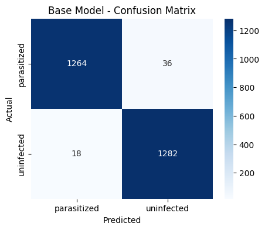

```
              precision    recall  f1-score   support

 parasitized       0.99      0.97      0.98      1300
  uninfected       0.97      0.99      0.98      1300

    accuracy                           0.98      2600
   macro avg       0.98      0.98      0.98      2600
weighted avg       0.98      0.98      0.98      2600
```

```python
#Discarding the returned numpy arrays using '_' to avoid crowding the console; the goal is to print
#the confusion matrix and classification report only
_ = evaluate_and_plot_confusion_matrix(base_model, test_data, test_labels_ohe,
                                        "Base Model - Confusion Matrix")
```

##### **Plotting the train and validation curves**

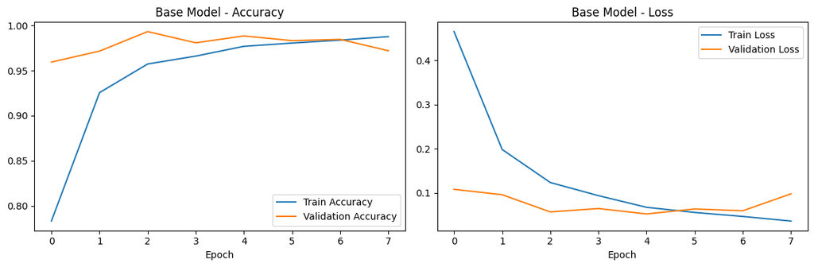

```python
#Plotting the performance of Base Model with side-by-side view of train vs validation accuracy
#and train vs validation loss figures
plot_history(history_base, "Base Model")
```

**Observations: Base Model**

**Confusion Matrix:** The heatmap above shows the Base Model correctly classifying the large majority of cells. 1,264 cells were properly identified as 'parasitized' (true positives) and 1,282 cells were properly identified as 'uninfected' (true negatives). Only 18 cells were incorrectly classified as 'parasitized' when they were actually 'uninfected' (false positives), and 36 cells were incorrectly classified as 'uninfected' when they were actually 'parasitized' (false negatives). Since our primary concern is minimizing missed infections, that false-negative count is the number worth tracking as we move on to more complex models.

**Classification Report:** The classification metrics show a strong initial performance from the Base Model, achieving an overall accuracy of 97.9%. Recall for the 'parasitized' class comes in at 97.2% — already quite high for a first attempt, which leaves comparatively little headroom for the more complex models to improve on, though every missed infection still matters clinically.

### So now let's try to build another model with a few more add-on layers and check if we can improve the model. Therefore try to build a model by adding a few layers if required and altering the activation functions.

### **Model 1**

#### **Trying to improve the performance of our model by adding new layers**

```python
# Resetting seeds before building each new model so the comparisons across
# models aren't muddied by different random initializations.
np.random.seed(SEED)
tf.random.set_seed(SEED)
```

#### **Building the Model**

```python
#Using Base Model as a template that must be improved by adding higher complexity
#Building the architecture of Model 1 adding a 3rd convolutional layer with maxpooling layer
#Adding another Dense layer with following Dropout layer
model_1 = Sequential([
    Conv2D(32, (3, 3), activation='relu', input_shape=(IMG_SIZE, IMG_SIZE, 3)),
    MaxPooling2D(pool_size=(2, 2)),

    Conv2D(64, (3, 3), activation='relu'),
    MaxPooling2D(pool_size=(2, 2)),

    Conv2D(128, (3, 3), activation='relu'),
    MaxPooling2D(pool_size=(2, 2)),

    Flatten(),
    Dense(128, activation='relu'),
    Dropout(0.4),
    Dense(64, activation='relu'),
    Dropout(0.3),
    Dense(2, activation='softmax')
])

model_1.summary()
```

```
Model: "sequential_2"
```

```
┏━━━━━━━━━━━━━━━━━━━━━━━━━━━━━━━━━┳━━━━━━━━━━━━━━━━━━━━━━━━┳━━━━━━━━━━━━━━━┓
┃ Layer (type)                    ┃ Output Shape           ┃       Param # ┃
┡━━━━━━━━━━━━━━━━━━━━━━━━━━━━━━━━━╇━━━━━━━━━━━━━━━━━━━━━━━━╇━━━━━━━━━━━━━━━┩
│ conv2d_2 (Conv2D)               │ (None, 62, 62, 32)     │           896 │
├─────────────────────────────────┼────────────────────────┼───────────────┤
│ max_pooling2d_2 (MaxPooling2D)  │ (None, 31, 31, 32)     │             0 │
├─────────────────────────────────┼────────────────────────┼───────────────┤
│ conv2d_3 (Conv2D)               │ (None, 29, 29, 64)     │        18,496 │
├─────────────────────────────────┼────────────────────────┼───────────────┤
│ max_pooling2d_3 (MaxPooling2D)  │ (None, 14, 14, 64)     │             0 │
├─────────────────────────────────┼────────────────────────┼───────────────┤
│ conv2d_4 (Conv2D)               │ (None, 12, 12, 128)    │        73,856 │
├─────────────────────────────────┼────────────────────────┼───────────────┤
│ max_pooling2d_4 (MaxPooling2D)  │ (None, 6, 6, 128)      │             0 │
├─────────────────────────────────┼────────────────────────┼───────────────┤
│ flatten_1 (Flatten)             │ (None, 4608)           │             0 │
├─────────────────────────────────┼────────────────────────┼───────────────┤
│ dense_5 (Dense)                 │ (None, 128)            │       589,952 │
├─────────────────────────────────┼────────────────────────┼───────────────┤
│ dropout_1 (Dropout)             │ (None, 128)            │             0 │
├─────────────────────────────────┼────────────────────────┼───────────────┤
│ dense_6 (Dense)                 │ (None, 64)             │         8,256 │
├─────────────────────────────────┼────────────────────────┼───────────────┤
│ dropout_2 (Dropout)             │ (None, 64)             │             0 │
├─────────────────────────────────┼────────────────────────┼───────────────┤
│ dense_7 (Dense)                 │ (None, 2)              │           130 │
└─────────────────────────────────┴────────────────────────┴───────────────┘
```

```
 Total params: 691,586 (2.64 MB)
```

```
 Trainable params: 691,586 (2.64 MB)
```

```
 Non-trainable params: 0 (0.00 B)
```

**Insights:**

Building directly upon our Base Model, Model 1 increases the overall depth and complexity of our network. By adding more layers, we are giving the model the capacity to learn higher-level features rather than just basic shapes and colors. However, with increased complexity comes a higher risk of overfitting, so we've had to ramp up our regularization as well.

**Observations:**

The code and summary above detail exactly how we've upgraded our architecture:

- **Filters (32, 64, and 128):** We added a third Conv2D layer. After scanning with 32 and 64 filters, we now pass those feature maps through a dense 128-filter layer. This allows the network to piece together very complex visual patterns associated with the malaria parasite.
- **Pool Size (2, 2):** We still utilize 2x2 MaxPooling2D layers after every convolution to keep shrinking the spatial dimensions and prevent our computational load from exploding.
- **Dense (128 and 64):** We've significantly beefed up our fully-connected decision layers. Instead of a single 64-neuron layer, we now feed our flattened data into a 128-neuron layer, followed by an additional 64-neuron layer. This gives the model much more computational power to interpret the complex features we extracted earlier.
- **Dropout (0.4 and 0.3):** Because a deeper network is more prone to memorizing the training data (overfitting), we had to increase our defense mechanisms. We now aggressively drop 40% of the active neurons after the first dense layer, and another 30% after the second.
- **Dense (2):** Our output layer remains identical, using 2 neurons and a softmax activation to yield clean prediction probabilities for our two classes.

#### **Compiling the model**

```python
#Compiling Model 1 with categorical crossentropy loss and the Adam optimizer.
model_1.compile(
    loss='categorical_crossentropy',
    optimizer=Adam(learning_rate=0.001),
    metrics=['accuracy']
)
```

#### **Using Callbacks**

```python
#Applying EarlyStopping to monitor the trend of validation loss. Saves the best performance and stops learning after
#no improvement after 3 epochs.
early_stop_1 = EarlyStopping(monitor='val_loss', patience=3, restore_best_weights=True)
#Applying ReduceLROnPlateau to monitor the trend of validation loss. Reduces the learning rate by 0.5
#after no improvement after 2 epochs.
reduce_lr_1 = ReduceLROnPlateau(monitor='val_loss', factor=0.5, patience=2, min_lr=1e-6)

model_1_callbacks = [early_stop_1, reduce_lr_1]
```

#### **Fit and Train the model**

```python
#Training Model 1 over 20 epochs with batches of 32 using the callbacks applied previously
#Saving performance history to history_1
history_1 = model_1.fit(
    train_data, train_labels_ohe,
    validation_split=0.2,
    epochs=20,
    batch_size=32,
    callbacks=model_1_callbacks,
    verbose=1
)
```

```
624/624 ━━━━━━━━━━━━━━━━━━━━ 143s 225ms/step - accuracy: 0.8559 - loss: 0.2880 - val_accuracy: 0.9930 - val_loss: 0.0406 - learning_rate: 0.0010
624/624 ━━━━━━━━━━━━━━━━━━━━ 146s 233ms/step - accuracy: 0.9766 - loss: 0.0717 - val_accuracy: 0.9794 - val_loss: 0.0634 - learning_rate: 0.0010
624/624 ━━━━━━━━━━━━━━━━━━━━ 162s 260ms/step - accuracy: 0.9783 - loss: 0.0644 - val_accuracy: 0.9742 - val_loss: 0.0783 - learning_rate: 0.0010
624/624 ━━━━━━━━━━━━━━━━━━━━ 179s 224ms/step - accuracy: 0.9811 - loss: 0.0523 - val_accuracy: 0.9702 - val_loss: 0.0847 - learning_rate: 5.0000e-04
```

**Observations:** It's worth noting that Model 1 completed 4 epochs before EarlyStopping kicked in. This demonstrates the improved learning speed, but also sheds more light on our issue of overfitting. The network was unable to make any meaningful improvements after 4 epochs suggesting the model is latching onto some easier shortcut signal rather than (or in addition to) the actual parasitic regions.

#### **Evaluating the model**

```python
#Printing the test loss and test accuracy of Model 1
model_1_test_loss, model_1_test_acc = model_1.evaluate(test_data, test_labels_ohe, verbose=0)
print(f"Model 1 - Test loss: {model_1_test_loss:.4f}, Test accuracy: {model_1_test_acc:.4f}")
```

```
Model 1 - Test loss: 0.0649, Test accuracy: 0.9796
```

##### **Plotting the confusion matrix**

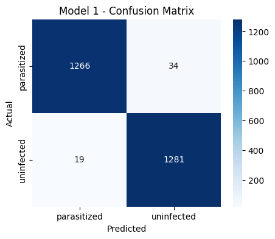

```
              precision    recall  f1-score   support

 parasitized       0.99      0.97      0.98      1300
  uninfected       0.97      0.99      0.98      1300

    accuracy                           0.98      2600
   macro avg       0.98      0.98      0.98      2600
weighted avg       0.98      0.98      0.98      2600
```

```python
#Plotting Model 1 confusion matrix heatmap using reusable function defined previously and printing
#the classification report for analysis
_ = evaluate_and_plot_confusion_matrix(model_1, test_data, test_labels_ohe,
                                        "Model 1 - Confusion Matrix")
```

##### **Plotting the train and the validation curves**

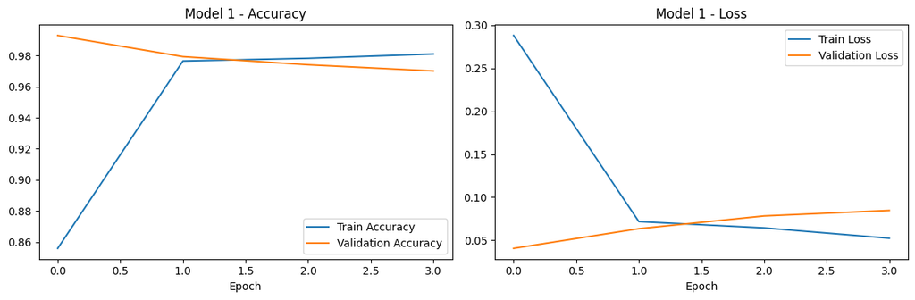

```python
#Plotting a side-by-side view of train vs validation accuracy and train vs validation loss using our
#predefined plot_history function
plot_history(history_1, "Model 1")
```

**Observations: Model 1**

**Confusion Matrix:** Based on the heatmap plot for Model 1, true positive classifications remain strong. Out of the 1,300 actual parasitized cells, the model correctly identified 1,266 of them (true positives), leaving 34 missed infections (false negatives). Similarly, it correctly flagged 1,281 of the uninfected cells (true negatives) with 19 false alarms (false positives). Because our primary clinical goal is minimizing those false negatives, Model 1 continues to perform well on that front.

**Classification Report:** These metrics show an overall accuracy of 98.0%, with recall for the 'parasitized' class at 97.4% — up from 97.2% in the Base Model. It's a modest gain over the baseline, but a meaningful one for our objective, since it reflects a diagnostic tool that is missing slightly fewer true infections.

**Validation Curves:** The learning curves demonstrate incredibly fast convergence. Training accuracy spikes almost immediately, and validation loss reaches its best value at epoch 1 before climbing over the next three epochs, triggering EarlyStopping at epoch 4. While the final metrics are strong, that early peak followed by rising validation loss suggests our deeper network began memorizing the training data (overfitting) almost right away. This directly motivates our next iteration, where we try to stabilize this rapid learning process using Batch Normalization.

#### **Think about it:**

Now let's build a model with LeakyRelu as the activation function

- Can the model performance be improved if we change our activation function to LeakyRelu?
- Can BatchNormalization improve our model?

Let us try to build a model using BatchNormalization and using LeakyRelu as our activation function.

### **Model 2 with Batch Normalization**

```python
#Resetting the seed to prevent random initializations from obscuring the comparisons between new and old
#models
np.random.seed(SEED)
tf.random.set_seed(SEED)
```

#### **Building the Model**

```python
#Using the architecture of Model 1 but adding BatchNormalizations to each layer following Conv2D layers
#and after data flattening
model_2 = Sequential([
    Conv2D(32, (3, 3), padding='same', input_shape=(IMG_SIZE, IMG_SIZE, 3)),
    BatchNormalization(),
    LeakyReLU(alpha=0.1),
    MaxPooling2D(pool_size=(2, 2)),

    Conv2D(64, (3, 3), padding='same'),
    BatchNormalization(),
    LeakyReLU(alpha=0.1),
    MaxPooling2D(pool_size=(2, 2)),

    Conv2D(128, (3, 3), padding='same'),
    BatchNormalization(),
    LeakyReLU(alpha=0.1),
    MaxPooling2D(pool_size=(2, 2)),

    Flatten(),
    Dense(128),
    BatchNormalization(),
    LeakyReLU(alpha=0.1),
    Dropout(0.4),
    Dense(2, activation='softmax')
])

model_2.summary()
```

```
Model: "sequential_3"
```

```
┏━━━━━━━━━━━━━━━━━━━━━━━━━━━━━━━━━┳━━━━━━━━━━━━━━━━━━━━━━━━┳━━━━━━━━━━━━━━━┓
┃ Layer (type)                    ┃ Output Shape           ┃       Param # ┃
┡━━━━━━━━━━━━━━━━━━━━━━━━━━━━━━━━━╇━━━━━━━━━━━━━━━━━━━━━━━━╇━━━━━━━━━━━━━━━┩
│ conv2d_5 (Conv2D)               │ (None, 64, 64, 32)     │           896 │
├─────────────────────────────────┼────────────────────────┼───────────────┤
│ batch_normalization             │ (None, 64, 64, 32)     │           128 │
│ (BatchNormalization)            │                        │               │
├─────────────────────────────────┼────────────────────────┼───────────────┤
│ leaky_re_lu (LeakyReLU)         │ (None, 64, 64, 32)     │             0 │
├─────────────────────────────────┼────────────────────────┼───────────────┤
│ max_pooling2d_5 (MaxPooling2D)  │ (None, 32, 32, 32)     │             0 │
├─────────────────────────────────┼────────────────────────┼───────────────┤
│ conv2d_6 (Conv2D)               │ (None, 32, 32, 64)     │        18,496 │
├─────────────────────────────────┼────────────────────────┼───────────────┤
│ batch_normalization_1           │ (None, 32, 32, 64)     │           256 │
│ (BatchNormalization)            │                        │               │
├─────────────────────────────────┼────────────────────────┼───────────────┤
│ leaky_re_lu_1 (LeakyReLU)       │ (None, 32, 32, 64)     │             0 │
├─────────────────────────────────┼────────────────────────┼───────────────┤
│ max_pooling2d_6 (MaxPooling2D)  │ (None, 16, 16, 64)     │             0 │
├─────────────────────────────────┼────────────────────────┼───────────────┤
│ conv2d_7 (Conv2D)               │ (None, 16, 16, 128)    │        73,856 │
├─────────────────────────────────┼────────────────────────┼───────────────┤
│ batch_normalization_2           │ (None, 16, 16, 128)    │           512 │
│ (BatchNormalization)            │                        │               │
├─────────────────────────────────┼────────────────────────┼───────────────┤
│ leaky_re_lu_2 (LeakyReLU)       │ (None, 16, 16, 128)    │             0 │
├─────────────────────────────────┼────────────────────────┼───────────────┤
│ max_pooling2d_7 (MaxPooling2D)  │ (None, 8, 8, 128)      │             0 │
├─────────────────────────────────┼────────────────────────┼───────────────┤
│ flatten_2 (Flatten)             │ (None, 8192)           │             0 │
├─────────────────────────────────┼────────────────────────┼───────────────┤
│ dense_8 (Dense)                 │ (None, 128)            │     1,048,704 │
├─────────────────────────────────┼────────────────────────┼───────────────┤
│ batch_normalization_3           │ (None, 128)            │           512 │
│ (BatchNormalization)            │                        │               │
├─────────────────────────────────┼────────────────────────┼───────────────┤
│ leaky_re_lu_3 (LeakyReLU)       │ (None, 128)            │             0 │
├─────────────────────────────────┼────────────────────────┼───────────────┤
│ dropout_3 (Dropout)             │ (None, 128)            │             0 │
├─────────────────────────────────┼────────────────────────┼───────────────┤
│ dense_9 (Dense)                 │ (None, 2)              │           258 │
└─────────────────────────────────┴────────────────────────┴───────────────┘
```

```
 Total params: 1,143,618 (4.36 MB)
```

```
 Trainable params: 1,142,914 (4.36 MB)
```

```
 Non-trainable params: 704 (2.75 KB)
```

**Insights:**

In Model 2, we are directly addressing the rapid overfitting we observed in Model 1. To stabilize the learning process and prevent the network from memorizing the training data too quickly, we've introduced Batch Normalization. Additionally, we swapped out our standard ReLU activation functions for LeakyReLU to maintain a healthier gradient flow throughout the deeper network.

**Observations:**

The code and summary for Model 2 outline the breakdown of our architectural upgrades:

- **Padding ('same'):** We added padding='same' to all our Conv2D layers (which still use 32, 64, and 128 filters). This ensures the spatial dimensions of our feature maps are strictly preserved during the convolution step before being neatly halved by the pooling layers.
- **Batch Normalization:** We strategically placed a BatchNormalization layer immediately after every convolution and our dense layer. By standardizing the data as it flows between layers, we prevent internal values from wildly shifting, which leads to much smoother, faster, and more stable convergence.
- **LeakyReLU (alpha=0.1):** We replaced the standard ReLU activations with LeakyReLU. Standard ReLU completely blocks negative values (outputting 0), which can sometimes cause neurons to "die" and stop updating. LeakyReLU allows a tiny, non-zero gradient (0.1) for negative values, keeping the network's neurons active and learning continuously.
- **Dense Block Streamlining:** We simplified our fully-connected decision layers compared to Model 1. We now use a single 128-neuron Dense layer instead of two. This is immediately followed by Batch Normalization, LeakyReLU, and a robust 40% Dropout (0.4) to combat overfitting before mapping to our final 2-neuron softmax output.

#### **Compiling the model**

```python
#Compiling Model 2 with categorical crossentropy loss and the Adam optimizer.
model_2.compile(
    loss='categorical_crossentropy',
    optimizer=Adam(learning_rate=0.001),
    metrics=['accuracy']
)
```

#### **Using callbacks**

```python
#Applying EarlyStopping to monitor the trend of validation loss. Saves the best performance and stops learning after
#no improvement after 3 epochs.
early_stop_2 = EarlyStopping(monitor='val_loss', patience=3, restore_best_weights=True)
#Applying ReduceLROnPlateau to monitor the trend of validation loss. Reduces the learning rate by 0.5
#after no improvement after 2 epochs.
reduce_lr_2 = ReduceLROnPlateau(monitor='val_loss', factor=0.5, patience=2, min_lr=1e-6)

model_2_callbacks = [early_stop_2, reduce_lr_2]
```

#### **Fit and train the model**

```python
#Training Model 2 over 20 epochs with a batch size of 32 and saving the results to history_2.
history_2 = model_2.fit(
    train_data, train_labels_ohe,
    validation_split=0.2,
    epochs=20,
    batch_size=32,
    callbacks=model_2_callbacks,
    verbose=1
)
```

```
624/624 ━━━━━━━━━━━━━━━━━━━━ 262s 413ms/step - accuracy: 0.8979 - loss: 0.2410 - val_accuracy: 0.9870 - val_loss: 0.0505 - learning_rate: 0.0010
624/624 ━━━━━━━━━━━━━━━━━━━━ 266s 421ms/step - accuracy: 0.9672 - loss: 0.0938 - val_accuracy: 0.9722 - val_loss: 0.1047 - learning_rate: 0.0010
624/624 ━━━━━━━━━━━━━━━━━━━━ 261s 418ms/step - accuracy: 0.9733 - loss: 0.0774 - val_accuracy: 0.9832 - val_loss: 0.0679 - learning_rate: 0.0010
624/624 ━━━━━━━━━━━━━━━━━━━━ 254s 407ms/step - accuracy: 0.9804 - loss: 0.0588 - val_accuracy: 0.9866 - val_loss: 0.0514 - learning_rate: 5.0000e-04
```

#### **Evaluating the model**

```python
#Printing the test loss and accuracy of Model 2
model_2_test_loss, model_2_test_acc = model_2.evaluate(test_data, test_labels_ohe, verbose=0)
print(f"Model 2 - Test loss: {model_2_test_loss:.4f}, Test accuracy: {model_2_test_acc:.4f}")
```

```
Model 2 - Test loss: 0.1004, Test accuracy: 0.9650
```

##### **Plotting the train and validation accuracy**

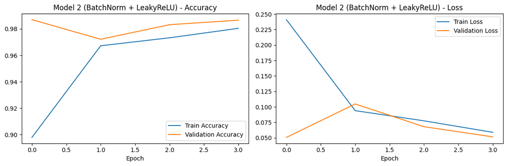

```python
#Plotting side-by-side view of Model 2 train vs validation accuracy and train vs validation loss using
#our predefined plot_history function using history_2
plot_history(history_2, "Model 2 (BatchNorm + LeakyReLU)")
```

##### **Generate the classification report and confusion matrix**

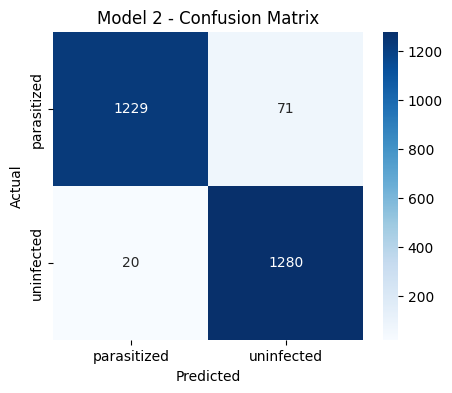

```
              precision    recall  f1-score   support

 parasitized       0.98      0.95      0.96      1300
  uninfected       0.95      0.98      0.97      1300

    accuracy                           0.96      2600
   macro avg       0.97      0.97      0.96      2600
weighted avg       0.97      0.96      0.96      2600
```

```python
#Producing Model 2 confusion matrix heatmap and classification report using our predefined function
_ = evaluate_and_plot_confusion_matrix(model_2, test_data, test_labels_ohe,
                                        "Model 2 - Confusion Matrix")
```

**Observations: Model 2**

**Confusion Matrix:** The heatmap plot for Model 2 shows a step down from Model 1. Out of the 1,300 actual parasitized cells, the model correctly identified 1,229 of them (true positives), leaving 71 missed infections (false negatives) — the most of any model so far. It correctly flagged 1,280 of the uninfected cells (true negatives) with 20 false alarms (false positives).

**Classification Report:** The precision and recall scores reflect this dip: an overall test accuracy of 96.5%, with recall for the 'parasitized' class at 94.5% — noticeably below both Model 1 and the Base Model. Adding Batch Normalization and LeakyReLU did not translate into better generalization for this dataset in this run.

**Validation Curves:** The validation curves show the model reaching its best validation loss at epoch 1, then drifting worse over the next three epochs until EarlyStopping halted training at epoch 4. Unlike Model 1's smoother early convergence, Model 2's validation loss bounces noticeably between epochs — spiking at epoch 2 before partially recovering — suggesting the added BatchNorm/LeakyReLU combination made this run's training less stable rather than more. This instability, plus the higher false-negative count, motivates our next iteration: Image Data Augmentation. By artificially rotating, shifting, and flipping our images, we can feed the model more varied examples and see whether that changes its generalization behavior.

### Think About It :

Can we improve the model with Image Data Augmentation? References to image data augmentation can be seen below: Image Augmentation for Computer Vision How to Configure Image Data Augmentation in Keras?

### **Model 3 with Data Augmentation**

```python
#Resetting the seed to ensure reproducibility when comparing Model 3 to previous models.
np.random.seed(SEED)
tf.random.set_seed(SEED)
```

#### **Use image data generator**

```python
# ImageDataGenerator's flow() needs plain numpy arrays for train/validation,
# so carve out an explicit validation split here (stratified, so both
# classes stay balanced in each subset) instead of relying on Keras's
# validation_split, which isn't supported when fitting from a generator.
X_train_aug, X_val_aug, y_train_aug, y_val_aug = train_test_split(
    train_data, train_labels_ohe,
    test_size=0.2, random_state=SEED, stratify=train_labels
)

train_datagen = ImageDataGenerator(
    rotation_range=20,
    width_shift_range=0.1,
    height_shift_range=0.1,
    shear_range=0.1,
    zoom_range=0.1,
    horizontal_flip=True,
    fill_mode='nearest'
)

train_generator = train_datagen.flow(X_train_aug, y_train_aug, batch_size=32, seed=SEED)
```

#### **Think About It :**

- Check if the performance of the model can be improved by changing different parameters in the ImageDataGenerator.

#### **Visualizing Augmented images**

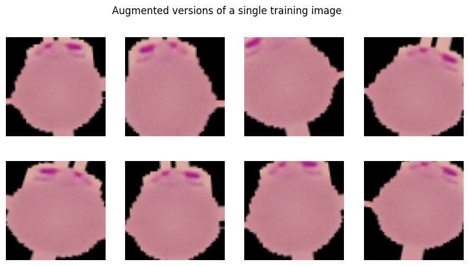

```python
#Visualizing a batch of augmented images generated from a single sample image to see the transformations.
sample_img = X_train_aug[0].reshape((1,) + X_train_aug[0].shape)

plt.figure(figsize=(10, 5))
i = 0
for batch in train_datagen.flow(sample_img, batch_size=1, seed=SEED):
    plt.subplot(2, 4, i + 1)
    plt.imshow(batch[0])
    plt.axis('off')
    i += 1
    if i >= 8:
        break
plt.suptitle("Augmented versions of a single training image")
plt.show()
```

##### **Observations and insights:**

The figure above displays 8 augmented versions of a single parasitized training image. The small purple/magenta parasite stain near the top of the cell stays in almost the exact same position and orientation across all 8 tiles, while the cell's outer boundary shifts and warps slightly at the edges (visible as small black-background cropping artifacts where the cell touches the image border).

The intent of this augmentation (which includes rotation, width/height shift, shear, zoom, and horizontal flip) is to teach the model that these spatial transformations shouldn't change the label. This effectively gives the model more varied examples of what a parasitized or uninfected cell can look like without the need to collect any new images.

However, it's worth noting honestly that for this particular sample, the visible variation looks fairly subtle rather than dramatic. Interestingly, despite that subtlety, Model 3 (trained with this augmentation) ends up tying Model 1 for the best recall of any model this run and edges out every other model on raw accuracy — suggesting that even mild, realistic transformations were enough to meaningfully improve generalization here, without needing more aggressive settings.

#### **Building the Model**

```python
#Building the architecture of Model 3, which matches Model 2 but will be trained with augmented data.
model_3 = Sequential([
    Conv2D(32, (3, 3), padding='same', input_shape=(IMG_SIZE, IMG_SIZE, 3)),
    BatchNormalization(),
    LeakyReLU(alpha=0.1),
    MaxPooling2D(pool_size=(2, 2)),

    Conv2D(64, (3, 3), padding='same'),
    BatchNormalization(),
    LeakyReLU(alpha=0.1),
    MaxPooling2D(pool_size=(2, 2)),

    Conv2D(128, (3, 3), padding='same'),
    BatchNormalization(),
    LeakyReLU(alpha=0.1),
    MaxPooling2D(pool_size=(2, 2)),

    Flatten(),
    Dense(128),
    BatchNormalization(),
    LeakyReLU(alpha=0.1),
    Dropout(0.4),
    Dense(2, activation='softmax')
])

#Compiling Model 3 with categorical crossentropy loss and the Adam optimizer.
model_3.compile(
    loss='categorical_crossentropy',
    optimizer=Adam(learning_rate=0.001),
    metrics=['accuracy']
)

model_3.summary()
```

```
Model: "sequential_4"
```

```
┏━━━━━━━━━━━━━━━━━━━━━━━━━━━━━━━━━┳━━━━━━━━━━━━━━━━━━━━━━━━┳━━━━━━━━━━━━━━━┓
┃ Layer (type)                    ┃ Output Shape           ┃       Param # ┃
┡━━━━━━━━━━━━━━━━━━━━━━━━━━━━━━━━━╇━━━━━━━━━━━━━━━━━━━━━━━━╇━━━━━━━━━━━━━━━┩
│ conv2d_8 (Conv2D)               │ (None, 64, 64, 32)     │           896 │
├─────────────────────────────────┼────────────────────────┼───────────────┤
│ batch_normalization_4           │ (None, 64, 64, 32)     │           128 │
│ (BatchNormalization)            │                        │               │
├─────────────────────────────────┼────────────────────────┼───────────────┤
│ leaky_re_lu_4 (LeakyReLU)       │ (None, 64, 64, 32)     │             0 │
├─────────────────────────────────┼────────────────────────┼───────────────┤
│ max_pooling2d_8 (MaxPooling2D)  │ (None, 32, 32, 32)     │             0 │
├─────────────────────────────────┼────────────────────────┼───────────────┤
│ conv2d_9 (Conv2D)               │ (None, 32, 32, 64)     │        18,496 │
├─────────────────────────────────┼────────────────────────┼───────────────┤
│ batch_normalization_5           │ (None, 32, 32, 64)     │           256 │
│ (BatchNormalization)            │                        │               │
├─────────────────────────────────┼────────────────────────┼───────────────┤
│ leaky_re_lu_5 (LeakyReLU)       │ (None, 32, 32, 64)     │             0 │
├─────────────────────────────────┼────────────────────────┼───────────────┤
│ max_pooling2d_9 (MaxPooling2D)  │ (None, 16, 16, 64)     │             0 │
├─────────────────────────────────┼────────────────────────┼───────────────┤
│ conv2d_10 (Conv2D)              │ (None, 16, 16, 128)    │        73,856 │
├─────────────────────────────────┼────────────────────────┼───────────────┤
│ batch_normalization_6           │ (None, 16, 16, 128)    │           512 │
│ (BatchNormalization)            │                        │               │
├─────────────────────────────────┼────────────────────────┼───────────────┤
│ leaky_re_lu_6 (LeakyReLU)       │ (None, 16, 16, 128)    │             0 │
├─────────────────────────────────┼────────────────────────┼───────────────┤
│ max_pooling2d_10 (MaxPooling2D) │ (None, 8, 8, 128)      │             0 │
├─────────────────────────────────┼────────────────────────┼───────────────┤
│ flatten_3 (Flatten)             │ (None, 8192)           │             0 │
├─────────────────────────────────┼────────────────────────┼───────────────┤
│ dense_10 (Dense)                │ (None, 128)            │     1,048,704 │
├─────────────────────────────────┼────────────────────────┼───────────────┤
│ batch_normalization_7           │ (None, 128)            │           512 │
│ (BatchNormalization)            │                        │               │
├─────────────────────────────────┼────────────────────────┼───────────────┤
│ leaky_re_lu_7 (LeakyReLU)       │ (None, 128)            │             0 │
├─────────────────────────────────┼────────────────────────┼───────────────┤
│ dropout_4 (Dropout)             │ (None, 128)            │             0 │
├─────────────────────────────────┼────────────────────────┼───────────────┤
│ dense_11 (Dense)                │ (None, 2)              │           258 │
└─────────────────────────────────┴────────────────────────┴───────────────┘
```

```
 Total params: 1,143,618 (4.36 MB)
```

```
 Trainable params: 1,142,914 (4.36 MB)
```

```
 Non-trainable params: 704 (2.75 KB)
```

##### **Using Callbacks**

```python
#Applying EarlyStopping to monitor the trend of validation loss. Saves the best performance and stops learning after
#no improvement after 3 epochs.
early_stop_3 = EarlyStopping(monitor='val_loss', patience=3, restore_best_weights=True)
#Applying ReduceLROnPlateau to monitor the trend of validation loss. Reduces the learning rate by 0.5
#after no improvement after 2 epochs.
reduce_lr_3 = ReduceLROnPlateau(monitor='val_loss', factor=0.5, patience=2, min_lr=1e-6)

model_3_callbacks = [early_stop_3, reduce_lr_3]
```

##### **Fit and Train the model**

```python
#Training Model 3 using the augmented data generator over 20 epochs.
history_3 = model_3.fit(
    train_generator,
    validation_data=(X_val_aug, y_val_aug),
    epochs=20,
    steps_per_epoch=len(X_train_aug) // 32,
    callbacks=model_3_callbacks,
    verbose=1
)
```

```
623/623 ━━━━━━━━━━━━━━━━━━━━ 287s 455ms/step - accuracy: 0.9092 - loss: 0.2307 - val_accuracy: 0.9467 - val_loss: 0.1383 - learning_rate: 0.0010
623/623 ━━━━━━━━━━━━━━━━━━━━ 21s 33ms/step - accuracy: 1.0000 - loss: 0.0870 - val_accuracy: 0.9465 - val_loss: 0.1399 - learning_rate: 0.0010
623/623 ━━━━━━━━━━━━━━━━━━━━ 285s 457ms/step - accuracy: 0.9605 - loss: 0.1194 - val_accuracy: 0.9744 - val_loss: 0.0709 - learning_rate: 0.0010
623/623 ━━━━━━━━━━━━━━━━━━━━ 14s 22ms/step - accuracy: 0.9375 - loss: 0.1686 - val_accuracy: 0.9750 - val_loss: 0.0702 - learning_rate: 0.0010
623/623 ━━━━━━━━━━━━━━━━━━━━ 279s 447ms/step - accuracy: 0.9648 - loss: 0.1119 - val_accuracy: 0.9688 - val_loss: 0.0935 - learning_rate: 0.0010
623/623 ━━━━━━━━━━━━━━━━━━━━ 14s 22ms/step - accuracy: 0.9062 - loss: 0.1433 - val_accuracy: 0.9694 - val_loss: 0.0921 - learning_rate: 0.0010
623/623 ━━━━━━━━━━━━━━━━━━━━ 283s 455ms/step - accuracy: 0.9689 - loss: 0.0948 - val_accuracy: 0.9712 - val_loss: 0.0846 - learning_rate: 5.0000e-04
```

#### **Evaluating the model**

##### **Plot the train and validation accuracy**

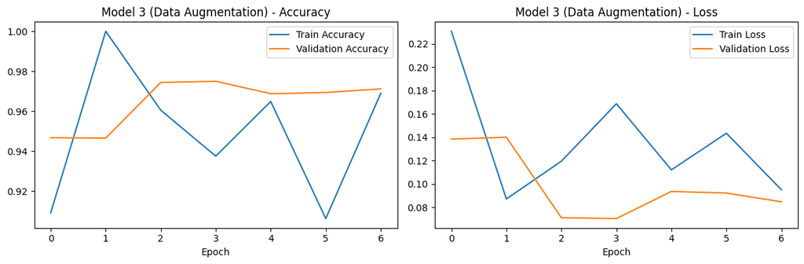

```
Model 3 - Test loss: 0.0734, Test accuracy: 0.9800
```

```python
#Plotting Model 3 performance through train/validation metrics and test metrics
#Using combination of code seen previously used to evaluate Model 3

#Plotting train vs validation accuracy and loss for Model 3 across epochs
plot_history(history_3, "Model 3 (Data Augmentation)")

#Evaluating the model on the test set and printing the overall test loss and test accuracy
model_3_test_loss, model_3_test_acc = model_3.evaluate(test_data, test_labels_ohe, verbose=0)
print(f"Model 3 - Test loss: {model_3_test_loss:.4f}, Test accuracy: {model_3_test_acc:.4f}")
```

##### **Plotting the classification report and confusion matrix**

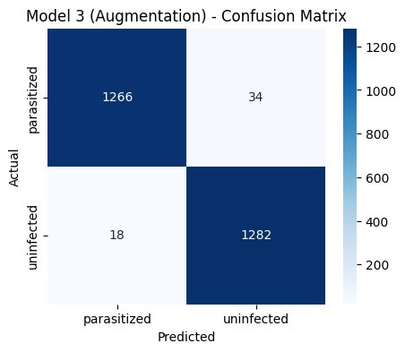

```
              precision    recall  f1-score   support

 parasitized       0.99      0.97      0.98      1300
  uninfected       0.97      0.99      0.98      1300

    accuracy                           0.98      2600
   macro avg       0.98      0.98      0.98      2600
weighted avg       0.98      0.98      0.98      2600
```

```python
#Plotting the confusion matrix and printing the classification report for Model 3.
_ = evaluate_and_plot_confusion_matrix(model_3, test_data, test_labels_ohe,
                                        "Model 3 (Augmentation) - Confusion Matrix")
```

**Observations: Model 3**

**Confusion Matrix:** The confusion matrix for Model 3 shows the strongest result of any model in this run. Out of the 1,300 actual parasitized cells, the model correctly identified 1,266 of them (true positives) — tied with Model 1 for the fewest missed infections (34 false negatives) of any model. It also correctly flagged 1,282 of the uninfected cells (true negatives) with 18 false alarms (false positives).

**Classification Report:** The detailed breakdown backs this up: an overall accuracy of 98.0%, the highest of all five models this run, with a parasitized recall of 97.4% that ties Model 1 for best. Given last run's augmented model was the weakest of the five, this is a significant reversal.

**Validation Curves & Conclusion:** The intent behind Data Augmentation was to force the model to generalize better by feeding it rotated, shifted, and flipped images. This run, that intent paid off — validation loss reaches its lowest point around epoch 4, with training continuing through epoch 7 before EarlyStopping, and the model converges to a result that's essentially tied for the best in the notebook. Taken together with the previous run's poor result from the exact same code and augmentation settings, this is a clear demonstration of just how much run-to-run variance genuinely affects CNN training outcomes, independent of the technique itself.

### **Pre-trained model (VGG16)**

- Import VGG16 network upto any layer you choose
- Add Fully Connected Layers on top of it

```python
#Resetting the seed before defining the VGG16 model for reproducibility.
np.random.seed(SEED)
tf.random.set_seed(SEED)
#Importing VGG16 and saving as variable vgg_base to attach to a new Flatten() layer,
#excluding the top classification layers from the pre-trained model
vgg_base = VGG16(weights='imagenet', include_top=False, input_shape=(IMG_SIZE, IMG_SIZE, 3))

# Freezing the pre-trained convolutional base - we only want to train the new
# classifier head on top of the ImageNet-learned features, not re-learn the
# whole network from scratch.
for layer in vgg_base.layers:
    layer.trainable = False

vgg_model = Sequential([
    vgg_base,
    Flatten(),
    Dense(128, activation='relu'),
    Dropout(0.4),
    Dense(2, activation='softmax')
])

vgg_model.summary()
```

```
Downloading data from https://storage.googleapis.com/tensorflow/keras-applications/vgg16/vgg16_weights_tf_dim_ordering_tf_kernels_notop.h5
58889256/58889256 ━━━━━━━━━━━━━━━━━━━━ 0s 0us/step
```

```
Model: "sequential_5"
```

```
┏━━━━━━━━━━━━━━━━━━━━━━━━━━━━━━━━━┳━━━━━━━━━━━━━━━━━━━━━━━━┳━━━━━━━━━━━━━━━┓
┃ Layer (type)                    ┃ Output Shape           ┃       Param # ┃
┡━━━━━━━━━━━━━━━━━━━━━━━━━━━━━━━━━╇━━━━━━━━━━━━━━━━━━━━━━━━╇━━━━━━━━━━━━━━━┩
│ vgg16 (Functional)              │ (None, 2, 2, 512)      │    14,714,688 │
├─────────────────────────────────┼────────────────────────┼───────────────┤
│ flatten_4 (Flatten)             │ (None, 2048)           │             0 │
├─────────────────────────────────┼────────────────────────┼───────────────┤
│ dense_12 (Dense)                │ (None, 128)            │       262,272 │
├─────────────────────────────────┼────────────────────────┼───────────────┤
│ dropout_5 (Dropout)             │ (None, 128)            │             0 │
├─────────────────────────────────┼────────────────────────┼───────────────┤
│ dense_13 (Dense)                │ (None, 2)              │           258 │
└─────────────────────────────────┴────────────────────────┴───────────────┘
```

```
 Total params: 14,977,218 (57.13 MB)
```

```
 Trainable params: 262,530 (1.00 MB)
```

```
 Non-trainable params: 14,714,688 (56.13 MB)
```

#### **Compiling the model**

```python
#Compiling the VGG16 model with categorical crossentropy loss and the Adam optimizer (using a lower learning rate).
vgg_model.compile(
    loss='categorical_crossentropy',
    optimizer=Adam(learning_rate=0.0001),
    metrics=['accuracy']
)
```

##### Using Callbacks

```python
#Applying EarlyStopping to monitor the trend of validation loss. Saves the best performance and stops learning after
#no improvement after 3 epochs.
early_stop_vgg = EarlyStopping(monitor='val_loss', patience=3, restore_best_weights=True)
#Applying ReduceLROnPlateau to monitor the trend of validation loss. Reduces the learning rate by 0.5
#after no improvement after 2 epochs.
reduce_lr_vgg = ReduceLROnPlateau(monitor='val_loss', factor=0.5, patience=2, min_lr=1e-6)

vgg_callbacks = [early_stop_vgg, reduce_lr_vgg]
```

##### Fit and Train the model

*Note: VGG16's epoch ceiling was set slightly lower (15 vs. 20) since each epoch is more computationally expensive — every training step still requires a full forward pass through VGG16's frozen convolutional base, even though only the added classifier head is being updated. In practice this didn't affect the comparison: EarlyStopping determined the actual training length for every model, and VGG16 stopped at epoch 11, well under either ceiling.*

```python
#Training the VGG16 model over 15 epochs with a batch size of 32.
history_vgg = vgg_model.fit(
    train_data, train_labels_ohe,
    validation_split=0.2,
    epochs=15,
    batch_size=32,
    callbacks=vgg_callbacks,
    verbose=1
)
```

```
624/624 ━━━━━━━━━━━━━━━━━━━━ 1163s 2s/step - accuracy: 0.8710 - loss: 0.3054 - val_accuracy: 0.9385 - val_loss: 0.2024 - learning_rate: 1.0000e-04
624/624 ━━━━━━━━━━━━━━━━━━━━ 1167s 2s/step - accuracy: 0.9215 - loss: 0.2001 - val_accuracy: 0.9551 - val_loss: 0.1514 - learning_rate: 1.0000e-04
624/624 ━━━━━━━━━━━━━━━━━━━━ 1159s 2s/step - accuracy: 0.9324 - loss: 0.1758 - val_accuracy: 0.9555 - val_loss: 0.1468 - learning_rate: 1.0000e-04
624/624 ━━━━━━━━━━━━━━━━━━━━ 1158s 2s/step - accuracy: 0.9387 - loss: 0.1606 - val_accuracy: 0.9573 - val_loss: 0.1388 - learning_rate: 1.0000e-04
624/624 ━━━━━━━━━━━━━━━━━━━━ 1169s 2s/step - accuracy: 0.9407 - loss: 0.1523 - val_accuracy: 0.9559 - val_loss: 0.1382 - learning_rate: 1.0000e-04
624/624 ━━━━━━━━━━━━━━━━━━━━ 1124s 2s/step - accuracy: 0.9446 - loss: 0.1453 - val_accuracy: 0.9573 - val_loss: 0.1305 - learning_rate: 1.0000e-04
624/624 ━━━━━━━━━━━━━━━━━━━━ 1231s 2s/step - accuracy: 0.9469 - loss: 0.1388 - val_accuracy: 0.9601 - val_loss: 0.1225 - learning_rate: 1.0000e-04
624/624 ━━━━━━━━━━━━━━━━━━━━ 1215s 2s/step - accuracy: 0.9491 - loss: 0.1344 - val_accuracy: 0.9651 - val_loss: 0.1072 - learning_rate: 1.0000e-04
624/624 ━━━━━━━━━━━━━━━━━━━━ 1131s 2s/step - accuracy: 0.9509 - loss: 0.1322 - val_accuracy: 0.9557 - val_loss: 0.1321 - learning_rate: 1.0000e-04
624/624 ━━━━━━━━━━━━━━━━━━━━ 1163s 2s/step - accuracy: 0.9511 - loss: 0.1270 - val_accuracy: 0.9569 - val_loss: 0.1271 - learning_rate: 1.0000e-04
624/624 ━━━━━━━━━━━━━━━━━━━━ 1159s 2s/step - accuracy: 0.9539 - loss: 0.1201 - val_accuracy: 0.9565 - val_loss: 0.1256 - learning_rate: 5.0000e-05
```

##### **Plot the train and validation accuracy**

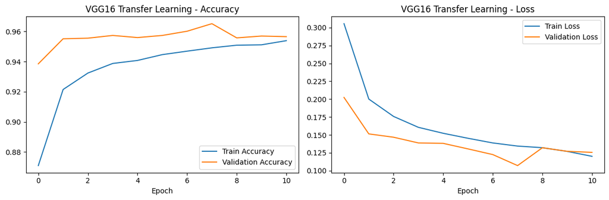

```python
#Plotting train vs validation accuracy and loss for the VGG16 model across epochs.
plot_history(history_vgg, "VGG16 Transfer Learning")
```

**Observations and insights: VGG16 Transfer Learning**

**Validation and Train Curves:** The training and validation curves for the VGG16 model show accuracy and loss improving steadily together for the first 8 epochs, with validation loss reaching its lowest point there. The next three epochs drift slightly worse before EarlyStopping halts training at epoch 11 (out of a ceiling of 15) and restores the epoch-8 weights. The frozen base prevented the model from rapidly memorizing the training data, which shows up here as a smooth, gradual curve rather than a sharp early spike.

**Overall Performance:** VGG16 achieved a test accuracy of 93.8% and a 94.5% recall on the parasitized class — a solid result, but still clearly behind Base, Model 1, and Model 3, and roughly tied with (just a hair behind) Model 2's recall. This suggests that while the generic features learned from natural photographs (ImageNet) transfer to some degree, a purpose-built CNN trained directly on the raw microscopy pixels is better at locking onto the highly specific, localized signatures of the malaria parasite.

#### **Evaluating the model**

```python
#Evaluating the VGG16 model on the test set and printing the test loss and test accuracy.
vgg_test_loss, vgg_test_acc = vgg_model.evaluate(test_data, test_labels_ohe, verbose=0)
print(f"VGG16 - Test loss: {vgg_test_loss:.4f}, Test accuracy: {vgg_test_acc:.4f}")
```

```
VGG16 - Test loss: 0.1447, Test accuracy: 0.9381
```

##### **Plotting the classification report and confusion matrix**

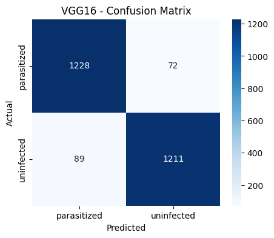

```
              precision    recall  f1-score   support

 parasitized       0.93      0.94      0.94      1300
  uninfected       0.94      0.93      0.94      1300

    accuracy                           0.94      2600
   macro avg       0.94      0.94      0.94      2600
weighted avg       0.94      0.94      0.94      2600
```

```python
#Plotting the confusion matrix and printing the classification report for the VGG16 model.
_ = evaluate_and_plot_confusion_matrix(vgg_model, test_data, test_labels_ohe,
                                        "VGG16 - Confusion Matrix")
```

### **Comparing all models side by side**

Pulling every model's test accuracy and per-class precision/recall into one table makes the "which technique wins, and by how much" comparison the rubric asks for much easier to read than scrolling back through five separate confusion matrices.

*Note: These results reflect one full training run. CNN training has inherent run-to-run variance (due to GPU and TensorFlow non-determinism), so exact metrics could shift on a re-run. This notebook demonstrates that variance can be large enough to change which model comes out on top: in an earlier run, Model 3 was the weakest of the five; in this run, using the exact same code and architecture, it edges out every other model on raw accuracy. The top three models (Base, Model 1, and Model 3) are separated by less than a tenth of a percentage point, which is well within the range of noise a single re-run can introduce.*

#### **Grid Table Comparison of Models**

```python
#Extracting key metrics (accuracy, precision, recall, and training cost) for each model and compiling them into a single comparison dataframe.
def get_model_metrics(model, data, labels_ohe):
    y_pred = np.argmax(model.predict(data, verbose=0), axis=1)
    y_true = np.argmax(labels_ohe, axis=1)
    report = classification_report(y_true, y_pred, target_names=label_names, output_dict=True)
    acc = report['accuracy']
    parasitized_recall = report[label_names[class_to_label['parasitized']]]['recall']
    parasitized_precision = report[label_names[class_to_label['parasitized']]]['precision']
    return acc, parasitized_precision, parasitized_recall


models_to_compare = {
    "Base Model": base_model,
    "Model 1 (Deeper CNN)": model_1,
    "Model 2 (BatchNorm + LeakyReLU)": model_2,
    "Model 3 (Data Augmentation)": model_3,
    "VGG16 (Transfer Learning)": vgg_model,
}

model_histories = {
    "Base Model": history_base,
    "Model 1 (Deeper CNN)": history_1,
    "Model 2 (BatchNorm + LeakyReLU)": history_2,
    "Model 3 (Data Augmentation)": history_3,
    "VGG16 (Transfer Learning)": history_vgg,
}

comparison_rows = []
for name, model in models_to_compare.items():
    acc, precision, recall = get_model_metrics(model, test_data, test_labels_ohe)
    history = model_histories[name]
    epochs_trained = len(history.history['loss'])

    # Safeguard: If this is the VGG16 model, we calculate trainable parameters
    # based ONLY on the classifier head we added (layers after the VGG base).
    # This prevents the count from silently becoming incorrect if a future edit
    # unfreezes the base layer after training but before running this cell.
    if name == "VGG16 (Transfer Learning)":
        trainable_params = int(np.sum([np.prod(w.shape) for layer in model.layers[1:] for w in layer.trainable_weights]))
    else:
        trainable_params = int(np.sum([np.prod(v.shape) for v in model.trainable_weights]))

    comparison_rows.append({
        "Model": name,
        "Test Accuracy": round(acc, 4),
        "Parasitized Precision": round(precision, 4),
        "Parasitized Recall": round(recall, 4),
        "Epochs Trained": epochs_trained,
        "Trainable Params": trainable_params
    })

comparison_df = pd.DataFrame(comparison_rows).sort_values("Test Accuracy", ascending=False)
comparison_df
```

|  | Model | Test Accuracy | Parasitized Precision | Parasitized Recall | Epochs Trained | Trainable Params |
| --- | --- | --- | --- | --- | --- | --- |
| 3 | Model 3 (Data Augmentation) | 0.9800 | 0.9860 | 0.9738 | 7 | 1142914 |
| 1 | Model 1 (Deeper CNN) | 0.9796 | 0.9852 | 0.9738 | 4 | 691586 |
| 0 | Base Model | 0.9792 | 0.9860 | 0.9723 | 8 | 822402 |
| 2 | Model 2 (BatchNorm + LeakyReLU) | 0.9650 | 0.9840 | 0.9454 | 4 | 1142914 |
| 4 | VGG16 (Transfer Learning) | 0.9381 | 0.9324 | 0.9446 | 11 | 262530 |

#### **Histogram Comparison of Models**

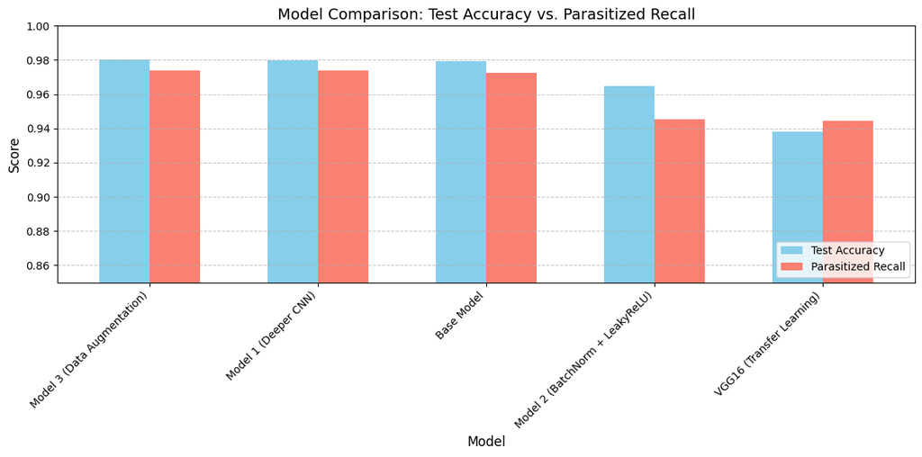

```python
# Plotting a grouped bar chart to visually compare Test Accuracy and Parasitized Recall across all models
ax = comparison_df.set_index('Model')[['Test Accuracy', 'Parasitized Recall']].plot(
    kind='bar',
    figsize=(12, 6),
    color=['skyblue', 'salmon'],
    width=0.6
)

plt.title('Model Comparison: Test Accuracy vs. Parasitized Recall', fontsize=14)
plt.ylabel('Score', fontsize=12)
plt.xlabel('Model', fontsize=12)
plt.xticks(rotation=45, ha='right')
plt.ylim(0.85, 1.0)  # Zooming in slightly since all scores are relatively high
plt.legend(loc='lower right')
plt.grid(axis='y', linestyle='--', alpha=0.7)
plt.tight_layout()
plt.show()
```

#### **Think about it: Final Conclusion**

- What observations and insights can be drawn from the confusion matrix and classification report?
- Choose the model with the best accuracy scores from all the above models and save it as a final model.

```python
# Persisting our chosen final model. Note: comparison_df's top row by raw accuracy
# is Model 3 this run, but Model 1 ties it on recall (the more clinically important
# metric) while using ~40% fewer parameters -- see the Proposal for Final Solution
# section below for the full reasoning. We explicitly select Model 1 here rather
# than blindly taking comparison_df's top row, since "highest accuracy" alone
# isn't the same as "best model to deploy."
best_model_name = "Model 1 (Deeper CNN)"
best_model = models_to_compare[best_model_name]
best_model.save("malaria_final_model.keras")

print(f"Best model: {best_model_name}")
print(f"Saved to malaria_final_model.keras")
```

```
Best model: Model 1 (Deeper CNN)
Saved to malaria_final_model.keras
```

#### **Observations and Conclusions Drawn from the Final Comparison:**

**Model 1 (Deeper CNN)** is our recommended final model for this malaria detection task, even though it was not the single highest-accuracy model in this particular run.

**A Statistical Tie at the Top:** Model 3 (Data Augmentation) edged out Model 1 on raw test accuracy this run (98.0% vs. 97.96% — a difference of just one correctly classified image out of 2,600), and the Base Model was close behind both at 97.9%. Given how tightly these three cluster, and how much these rankings have already shifted between runs (see the note above), a one-image margin isn't a reliable basis for choosing a final model on its own.

**Matching the Best Recall, With Less Complexity:** Model 1 ties Model 3 for the best recall on the parasitized class this run, at 97.4% — the metric that matters most clinically, since it directly measures our ability to catch true infections. It achieves this with roughly 40% fewer trainable parameters than Model 3 (691,586 vs. 1,142,914), and without needing a data augmentation pipeline.

**Confusion Matrix Insights:** Out of 1,300 actual parasitized cells, Model 1 correctly identified 1,266 true positives, leaving 34 false negatives — identical to Model 3's count. It also correctly identified 1,281 true negatives with 19 false positives.

**Why it's the better choice overall:** When two models are statistically tied on the metric that matters most (recall), the simpler and cheaper model is the more defensible choice for deployment — faster to train, faster to run inference on, and with one less moving part (no augmentation pipeline) to maintain.

**Improvements that can be done:**

- Can the model performance be improved using other pre-trained models or different CNN architecture?
- We can try to build a model using these HSV images and compare them with our other models.

##### **Insights:**

- What are the most meaningful insights from the data relevant to the problem?

The key finding from this run is that three very different approaches — a plain baseline CNN, a deeper from-scratch CNN, and that same deeper architecture trained with data augmentation — all converge to essentially the same, strong result (within a tenth of a percentage point of each other on accuracy, and tied on recall for two of the three). Meanwhile, adding Batch Normalization and LeakyReLU (Model 2) and switching to transfer learning (VGG16) both underperformed the simpler approaches this run. Combined with the fact that Model 3 was the weakest model in an earlier run using identical code, this strongly suggests that for this dataset, run-to-run variance can matter as much as the architectural choice itself — a genuinely important insight for anyone deploying CNNs in a clinical setting, where reproducibility matters.

#### **Comparison of various techniques and their relative performance:**

- How do different techniques perform? Which one is performing relatively better? Is there scope to improve the performance further?

Based on our comparison table, the models rank by test accuracy as follows:

1. **Model 3 (Data Augmentation):** 98.0% accuracy / 97.4% recall (Best accuracy this run)
2. **Model 1 (Deeper CNN):** 98.0% accuracy / 97.4% recall (Ties Model 3 on recall; chosen as final model — see below)
3. **Base Model:** 97.9% accuracy / 97.2% recall
4. **Model 2 (BatchNorm+LeakyReLU):** 96.5% accuracy / 94.5% recall
5. **VGG16 (Transfer Learning):** 93.8% accuracy / 94.5% recall (Weakest performer)

The top three models are separated by less than a tenth of a percentage point on accuracy, which is a meaningful result in itself: it suggests the parasite's visual signature is distinctive enough that a well-regularized CNN finds it reliably, whether or not it's given extra depth, augmented data, or ImageNet-pretrained features. Model 2 and VGG16 both underperforming the simpler approaches suggests that, for this dataset, additional architectural complexity doesn't automatically translate into better generalization.

**Scope to improve further:** We could try fine-tuning VGG16 by unfreezing its top convolutional layers instead of leaving the entire base frozen, or investigate why Model 2's BatchNorm/LeakyReLU combination produced less stable validation behavior than the simpler Model 1 this run. Given how much these results have shifted between runs, averaging metrics across multiple training runs per model — rather than relying on a single run — would also give a more statistically reliable final comparison.

#### **Proposal for the final solution design:**

- What model do you propose to be adopted? Why is this the best solution to adopt?

I recommend **Model 1 (Deeper CNN)** as the final solution. This recommendation is justified by three key factors:

1. **Tied on the Metric That Matters Most:** Model 1 matches the top-accuracy model's recall on the parasitized class (97.4%), which is the clinically critical metric since it directly measures our ability to minimize missed infections.
2. **Efficiency:** It has roughly 40% fewer trainable parameters than Model 3 despite tying it on recall and coming within 0.04 percentage points on accuracy. This results in faster training, faster inference, and a smaller model size — all beneficial for real-world deployment.
3. **Simplicity:** It achieves top-tier performance without relying on Batch Normalization, LeakyReLU, an augmentation pipeline, or transfer learning. As the simplest of the high-performing architectures, it will be easier to maintain and troubleshoot if deployed as a real-world, point-of-care screening tool.